# NSL-KDD

Network security is becoming increasingly important because of the massive expansion of computer networks' usage and the number of applications built on top of them, while all systems experience security flaws that could lead to an increase in attacks that could have a negative impact on the economy. Therefore, detecting vulnerabilities in the system in the network has become more important and needs to be done as accurately as possible in real-time.

Here are the goals of this exploration:

We apply machine learning and deep learning algorithms

- *-Logistic Regression
- *-GaussianNB
- *-Stochastic Gradient Descent (SGD)
- *-Linear Discriminant Analysis (LDA)
- *-K-Nearest Neighbor(KNN)
- *-K-Nearest Neighbor(KNN)with Bee
- *-LSTM
- *-CNN
- *-ANN-1
- *-ANN-2
- *-RNN
- *-GRU
- *-GRU with Bee
- - To evaluate the performance or quality of the model, different performances such as Accuracy, Precision, Recall, F1 Score, MCC, AUC, and confusion matrix

M. Tavallaee, E. Bagheri, W. Lu, and A. Ghorbani, "A detailed analysis of the KDD CUP 99 data set," in Proc. 2nd IEEE Symp. Comput. Intell. Secur. Defense Appl. (CISDA), 2009.

```python
import numpy as np
import pandas as pd
import matplotlib.pyplot as plt
import seaborn as sns
from keras.models import Sequential
from keras.layers import Dense, Activation ,Dropout , Flatten , Conv1D , MaxPooling1D,BatchNormalization, SpatialDropout1D,AveragePooling1D,SeparableConv1D
from keras.layers import LSTM
import tensorflow as tf
from keras import losses
from tensorflow.keras import layers
from tensorflow.keras import regularizers
from keras import optimizers
from keras import layers
import keras
from sklearn.metrics import accuracy_score
from sklearn.model_selection import train_test_split
from sklearn.preprocessing import LabelEncoder
from sklearn.metrics import precision_score, recall_score, f1_score, matthews_corrcoef, roc_auc_score, classification_report, confusion_matrix, roc_curve
from tensorflow.keras.models import Sequential
from tensorflow.keras.layers import SimpleRNN, Dropout, Flatten, Dense, Activation
from keras.layers import GRU, Dropout
import time
from tensorflow.keras.models import Sequential
from tensorflow.keras.layers import Dense, Dropout, BatchNormalization
from tensorflow.keras.constraints import MaxNorm
import numpy as np
import matplotlib.pyplot as plt
import seaborn as sns
from sklearn.metrics import accuracy_score, precision_score, recall_score, f1_score, matthews_corrcoef, roc_auc_score, classification_report, confusion_matrix, roc_curve

import warnings
#Turn off the warnings.
warnings.filterwarnings(action='ignore')
%matplotlib inline
```

[output not shown]

```python
# Load the datasets
df_train = pd.read_csv('/input/testing2/KDDTrain.txt', header=None, names=None)
df_test = pd.read_csv('/input/testing2/KDDTrain.txt', header=None, names=None)

# Combine the datasets
df = pd.concat([df_train, df_test], ignore_index=True)

# Verify the result
df
```

|  | 0 | 1 | 2 | 3 | 4 | 5 | 6 | 7 | 8 | 9 | ... | 33 | 34 | 35 | 36 | 37 | 38 | 39 | 40 | 41 | 42 |
| --- | --- | --- | --- | --- | --- | --- | --- | --- | --- | --- | --- | --- | --- | --- | --- | --- | --- | --- | --- | --- | --- |
| 0 | 0 | tcp | ftp_data | SF | 491 | 0 | 0 | 0 | 0 | 0 | ... | 0.17 | 0.03 | 0.17 | 0.00 | 0.00 | 0.00 | 0.05 | 0.00 | normal | 20 |
| 1 | 0 | udp | other | SF | 146 | 0 | 0 | 0 | 0 | 0 | ... | 0.00 | 0.60 | 0.88 | 0.00 | 0.00 | 0.00 | 0.00 | 0.00 | normal | 15 |
| 2 | 0 | tcp | private | S0 | 0 | 0 | 0 | 0 | 0 | 0 | ... | 0.10 | 0.05 | 0.00 | 0.00 | 1.00 | 1.00 | 0.00 | 0.00 | neptune | 19 |
| 3 | 0 | tcp | http | SF | 232 | 8153 | 0 | 0 | 0 | 0 | ... | 1.00 | 0.00 | 0.03 | 0.04 | 0.03 | 0.01 | 0.00 | 0.01 | normal | 21 |
| 4 | 0 | tcp | http | SF | 199 | 420 | 0 | 0 | 0 | 0 | ... | 1.00 | 0.00 | 0.00 | 0.00 | 0.00 | 0.00 | 0.00 | 0.00 | normal | 21 |
| ... | ... | ... | ... | ... | ... | ... | ... | ... | ... | ... | ... | ... | ... | ... | ... | ... | ... | ... | ... | ... | ... |
| 251941 | 0 | tcp | private | S0 | 0 | 0 | 0 | 0 | 0 | 0 | ... | 0.10 | 0.06 | 0.00 | 0.00 | 1.00 | 1.00 | 0.00 | 0.00 | neptune | 20 |
| 251942 | 8 | udp | private | SF | 105 | 145 | 0 | 0 | 0 | 0 | ... | 0.96 | 0.01 | 0.01 | 0.00 | 0.00 | 0.00 | 0.00 | 0.00 | normal | 21 |
| 251943 | 0 | tcp | smtp | SF | 2231 | 384 | 0 | 0 | 0 | 0 | ... | 0.12 | 0.06 | 0.00 | 0.00 | 0.72 | 0.00 | 0.01 | 0.00 | normal | 18 |
| 251944 | 0 | tcp | klogin | S0 | 0 | 0 | 0 | 0 | 0 | 0 | ... | 0.03 | 0.05 | 0.00 | 0.00 | 1.00 | 1.00 | 0.00 | 0.00 | neptune | 20 |
| 251945 | 0 | tcp | ftp_data | SF | 151 | 0 | 0 | 0 | 0 | 0 | ... | 0.30 | 0.03 | 0.30 | 0.00 | 0.00 | 0.00 | 0.00 | 0.00 | normal | 21 |

251946 rows × 43 columns

```python
# add the column labels
columns = (['duration'
,'protocol_type'
,'service'
,'flag'
,'src_bytes'
,'dst_bytes'
,'land'
,'wrong_fragment'
,'urgent'
,'hot'
,'num_failed_logins'
,'logged_in'
,'num_compromised'
,'root_shell'
,'su_attempted'
,'num_root'
,'num_file_creations'
,'num_shells'
,'num_access_files'
,'num_outbound_cmds'
,'is_host_login'
,'is_guest_login'
,'count'
,'srv_count'
,'serror_rate'
,'srv_serror_rate'
,'rerror_rate'
,'srv_rerror_rate'
,'same_srv_rate'
,'diff_srv_rate'
,'srv_diff_host_rate'
,'dst_host_count'
,'dst_host_srv_count'
,'dst_host_same_srv_rate'
,'dst_host_diff_srv_rate'
,'dst_host_same_src_port_rate'
,'dst_host_srv_diff_host_rate'
,'dst_host_serror_rate'
,'dst_host_srv_serror_rate'
,'dst_host_rerror_rate'
,'dst_host_srv_rerror_rate'
,'attack'
,'level'])
```

```python
df.columns
```

```
Index([ 0,  1,  2,  3,  4,  5,  6,  7,  8,  9, 10, 11, 12, 13, 14, 15, 16, 17,
       18, 19, 20, 21, 22, 23, 24, 25, 26, 27, 28, 29, 30, 31, 32, 33, 34, 35,
       36, 37, 38, 39, 40, 41, 42],
      dtype='int64')
```

```python
df.columns = columns
```

```python
df.isnull().sum()
```

```
duration                       0
protocol_type                  0
service                        0
flag                           0
src_bytes                      0
dst_bytes                      0
land                           0
wrong_fragment                 0
urgent                         0
hot                            0
num_failed_logins              0
logged_in                      0
num_compromised                0
root_shell                     0
su_attempted                   0
num_root                       0
num_file_creations             0
num_shells                     0
num_access_files               0
num_outbound_cmds              0
is_host_login                  0
is_guest_login                 0
count                          0
srv_count                      0
serror_rate                    0
srv_serror_rate                0
rerror_rate                    0
srv_rerror_rate                0
same_srv_rate                  0
diff_srv_rate                  0
srv_diff_host_rate             0
dst_host_count                 0
dst_host_srv_count             0
dst_host_same_srv_rate         0
dst_host_diff_srv_rate         0
dst_host_same_src_port_rate    0
dst_host_srv_diff_host_rate    0
dst_host_serror_rate           0
dst_host_srv_serror_rate       0
dst_host_rerror_rate           0
dst_host_srv_rerror_rate       0
attack                         0
level                          0
dtype: int64
```

```python
df.info()
```

```
<class 'pandas.core.frame.DataFrame'>
RangeIndex: 251946 entries, 0 to 251945
Data columns (total 43 columns):
 #   Column                       Non-Null Count   Dtype
---  ------                       --------------   -----
 0   duration                     251946 non-null  int64
 1   protocol_type                251946 non-null  object
 2   service                      251946 non-null  object
 3   flag                         251946 non-null  object
 4   src_bytes                    251946 non-null  int64
 5   dst_bytes                    251946 non-null  int64
 6   land                         251946 non-null  int64
 7   wrong_fragment               251946 non-null  int64
 8   urgent                       251946 non-null  int64
 9   hot                          251946 non-null  int64
```

[output cut: 35 more lines]

```python
df = df.dropna()

print(df.isnull().sum())
```

```
duration                       0
protocol_type                  0
service                        0
flag                           0
src_bytes                      0
dst_bytes                      0
land                           0
wrong_fragment                 0
urgent                         0
hot                            0
num_failed_logins              0
logged_in                      0
num_compromised                0
root_shell                     0
su_attempted                   0
num_root                       0
num_file_creations             0
num_shells                     0
num_access_files               0
num_outbound_cmds              0
is_host_login                  0
is_guest_login                 0
count                          0
srv_count                      0
serror_rate                    0
srv_serror_rate                0
rerror_rate                    0
srv_rerror_rate                0
same_srv_rate                  0
diff_srv_rate                  0
srv_diff_host_rate             0
dst_host_count                 0
dst_host_srv_count             0
dst_host_same_srv_rate         0
dst_host_diff_srv_rate         0
dst_host_same_src_port_rate    0
dst_host_srv_diff_host_rate    0
dst_host_serror_rate           0
dst_host_srv_serror_rate       0
dst_host_rerror_rate           0
dst_host_srv_rerror_rate       0
attack                         0
level                          0
dtype: int64
```

```python
df.isnull().sum()
```

```
duration                       0
protocol_type                  0
service                        0
flag                           0
src_bytes                      0
dst_bytes                      0
land                           0
wrong_fragment                 0
urgent                         0
hot                            0
num_failed_logins              0
logged_in                      0
num_compromised                0
root_shell                     0
su_attempted                   0
num_root                       0
num_file_creations             0
num_shells                     0
num_access_files               0
num_outbound_cmds              0
is_host_login                  0
is_guest_login                 0
count                          0
srv_count                      0
serror_rate                    0
srv_serror_rate                0
rerror_rate                    0
srv_rerror_rate                0
same_srv_rate                  0
diff_srv_rate                  0
srv_diff_host_rate             0
dst_host_count                 0
dst_host_srv_count             0
dst_host_same_srv_rate         0
dst_host_diff_srv_rate         0
dst_host_same_src_port_rate    0
dst_host_srv_diff_host_rate    0
dst_host_serror_rate           0
dst_host_srv_serror_rate       0
dst_host_rerror_rate           0
dst_host_srv_rerror_rate       0
attack                         0
level                          0
dtype: int64
```

```python
df.columns
```

```
Index(['duration', 'protocol_type', 'service', 'flag', 'src_bytes',
       'dst_bytes', 'land', 'wrong_fragment', 'urgent', 'hot',
       'num_failed_logins', 'logged_in', 'num_compromised', 'root_shell',
       'su_attempted', 'num_root', 'num_file_creations', 'num_shells',
       'num_access_files', 'num_outbound_cmds', 'is_host_login',
       'is_guest_login', 'count', 'srv_count', 'serror_rate',
       'srv_serror_rate', 'rerror_rate', 'srv_rerror_rate', 'same_srv_rate',
       'diff_srv_rate', 'srv_diff_host_rate', 'dst_host_count',
       'dst_host_srv_count', 'dst_host_same_srv_rate',
       'dst_host_diff_srv_rate', 'dst_host_same_src_port_rate',
       'dst_host_srv_diff_host_rate', 'dst_host_serror_rate',
       'dst_host_srv_serror_rate', 'dst_host_rerror_rate',
       'dst_host_srv_rerror_rate', 'attack', 'level'],
      dtype='object')
```

## Understanding our data:

- information and visualization

```python
print(F'Shape Train Data :',df.shape)
```

```
Shape Train Data : (251946, 43)
```

```python
df
```

|  | duration | protocol_type | service | flag | src_bytes | dst_bytes | land | wrong_fragment | urgent | hot | ... | dst_host_same_srv_rate | dst_host_diff_srv_rate | dst_host_same_src_port_rate | dst_host_srv_diff_host_rate | dst_host_serror_rate | dst_host_srv_serror_rate | dst_host_rerror_rate | dst_host_srv_rerror_rate | attack | level |
| --- | --- | --- | --- | --- | --- | --- | --- | --- | --- | --- | --- | --- | --- | --- | --- | --- | --- | --- | --- | --- | --- |
| 0 | 0 | tcp | ftp_data | SF | 491 | 0 | 0 | 0 | 0 | 0 | ... | 0.17 | 0.03 | 0.17 | 0.00 | 0.00 | 0.00 | 0.05 | 0.00 | normal | 20 |
| 1 | 0 | udp | other | SF | 146 | 0 | 0 | 0 | 0 | 0 | ... | 0.00 | 0.60 | 0.88 | 0.00 | 0.00 | 0.00 | 0.00 | 0.00 | normal | 15 |
| 2 | 0 | tcp | private | S0 | 0 | 0 | 0 | 0 | 0 | 0 | ... | 0.10 | 0.05 | 0.00 | 0.00 | 1.00 | 1.00 | 0.00 | 0.00 | neptune | 19 |
| 3 | 0 | tcp | http | SF | 232 | 8153 | 0 | 0 | 0 | 0 | ... | 1.00 | 0.00 | 0.03 | 0.04 | 0.03 | 0.01 | 0.00 | 0.01 | normal | 21 |
| 4 | 0 | tcp | http | SF | 199 | 420 | 0 | 0 | 0 | 0 | ... | 1.00 | 0.00 | 0.00 | 0.00 | 0.00 | 0.00 | 0.00 | 0.00 | normal | 21 |
| ... | ... | ... | ... | ... | ... | ... | ... | ... | ... | ... | ... | ... | ... | ... | ... | ... | ... | ... | ... | ... | ... |
| 251941 | 0 | tcp | private | S0 | 0 | 0 | 0 | 0 | 0 | 0 | ... | 0.10 | 0.06 | 0.00 | 0.00 | 1.00 | 1.00 | 0.00 | 0.00 | neptune | 20 |
| 251942 | 8 | udp | private | SF | 105 | 145 | 0 | 0 | 0 | 0 | ... | 0.96 | 0.01 | 0.01 | 0.00 | 0.00 | 0.00 | 0.00 | 0.00 | normal | 21 |
| 251943 | 0 | tcp | smtp | SF | 2231 | 384 | 0 | 0 | 0 | 0 | ... | 0.12 | 0.06 | 0.00 | 0.00 | 0.72 | 0.00 | 0.01 | 0.00 | normal | 18 |
| 251944 | 0 | tcp | klogin | S0 | 0 | 0 | 0 | 0 | 0 | 0 | ... | 0.03 | 0.05 | 0.00 | 0.00 | 1.00 | 1.00 | 0.00 | 0.00 | neptune | 20 |
| 251945 | 0 | tcp | ftp_data | SF | 151 | 0 | 0 | 0 | 0 | 0 | ... | 0.30 | 0.03 | 0.30 | 0.00 | 0.00 | 0.00 | 0.00 | 0.00 | normal | 21 |

251946 rows × 43 columns

```python
# The total missing values in the Data Train ?
print('Number of Missing Values :' , df.isna().sum().sum())
print('We do not have Miss Values in the Data ')
```

```
Number of Missing Values : 0
We do not have Miss Values in the Data
```

```python
df
```

|  | duration | protocol_type | service | flag | src_bytes | dst_bytes | land | wrong_fragment | urgent | hot | ... | dst_host_same_srv_rate | dst_host_diff_srv_rate | dst_host_same_src_port_rate | dst_host_srv_diff_host_rate | dst_host_serror_rate | dst_host_srv_serror_rate | dst_host_rerror_rate | dst_host_srv_rerror_rate | attack | level |
| --- | --- | --- | --- | --- | --- | --- | --- | --- | --- | --- | --- | --- | --- | --- | --- | --- | --- | --- | --- | --- | --- |
| 0 | 0 | tcp | ftp_data | SF | 491 | 0 | 0 | 0 | 0 | 0 | ... | 0.17 | 0.03 | 0.17 | 0.00 | 0.00 | 0.00 | 0.05 | 0.00 | normal | 20 |
| 1 | 0 | udp | other | SF | 146 | 0 | 0 | 0 | 0 | 0 | ... | 0.00 | 0.60 | 0.88 | 0.00 | 0.00 | 0.00 | 0.00 | 0.00 | normal | 15 |
| 2 | 0 | tcp | private | S0 | 0 | 0 | 0 | 0 | 0 | 0 | ... | 0.10 | 0.05 | 0.00 | 0.00 | 1.00 | 1.00 | 0.00 | 0.00 | neptune | 19 |
| 3 | 0 | tcp | http | SF | 232 | 8153 | 0 | 0 | 0 | 0 | ... | 1.00 | 0.00 | 0.03 | 0.04 | 0.03 | 0.01 | 0.00 | 0.01 | normal | 21 |
| 4 | 0 | tcp | http | SF | 199 | 420 | 0 | 0 | 0 | 0 | ... | 1.00 | 0.00 | 0.00 | 0.00 | 0.00 | 0.00 | 0.00 | 0.00 | normal | 21 |
| ... | ... | ... | ... | ... | ... | ... | ... | ... | ... | ... | ... | ... | ... | ... | ... | ... | ... | ... | ... | ... | ... |
| 251941 | 0 | tcp | private | S0 | 0 | 0 | 0 | 0 | 0 | 0 | ... | 0.10 | 0.06 | 0.00 | 0.00 | 1.00 | 1.00 | 0.00 | 0.00 | neptune | 20 |
| 251942 | 8 | udp | private | SF | 105 | 145 | 0 | 0 | 0 | 0 | ... | 0.96 | 0.01 | 0.01 | 0.00 | 0.00 | 0.00 | 0.00 | 0.00 | normal | 21 |
| 251943 | 0 | tcp | smtp | SF | 2231 | 384 | 0 | 0 | 0 | 0 | ... | 0.12 | 0.06 | 0.00 | 0.00 | 0.72 | 0.00 | 0.01 | 0.00 | normal | 18 |
| 251944 | 0 | tcp | klogin | S0 | 0 | 0 | 0 | 0 | 0 | 0 | ... | 0.03 | 0.05 | 0.00 | 0.00 | 1.00 | 1.00 | 0.00 | 0.00 | neptune | 20 |
| 251945 | 0 | tcp | ftp_data | SF | 151 | 0 | 0 | 0 | 0 | 0 | ... | 0.30 | 0.03 | 0.30 | 0.00 | 0.00 | 0.00 | 0.00 | 0.00 | normal | 21 |

251946 rows × 43 columns

```python
df
```

|  | duration | protocol_type | service | flag | src_bytes | dst_bytes | land | wrong_fragment | urgent | hot | ... | dst_host_same_srv_rate | dst_host_diff_srv_rate | dst_host_same_src_port_rate | dst_host_srv_diff_host_rate | dst_host_serror_rate | dst_host_srv_serror_rate | dst_host_rerror_rate | dst_host_srv_rerror_rate | attack | level |
| --- | --- | --- | --- | --- | --- | --- | --- | --- | --- | --- | --- | --- | --- | --- | --- | --- | --- | --- | --- | --- | --- |
| 0 | 0 | tcp | ftp_data | SF | 491 | 0 | 0 | 0 | 0 | 0 | ... | 0.17 | 0.03 | 0.17 | 0.00 | 0.00 | 0.00 | 0.05 | 0.00 | normal | 20 |
| 1 | 0 | udp | other | SF | 146 | 0 | 0 | 0 | 0 | 0 | ... | 0.00 | 0.60 | 0.88 | 0.00 | 0.00 | 0.00 | 0.00 | 0.00 | normal | 15 |
| 2 | 0 | tcp | private | S0 | 0 | 0 | 0 | 0 | 0 | 0 | ... | 0.10 | 0.05 | 0.00 | 0.00 | 1.00 | 1.00 | 0.00 | 0.00 | neptune | 19 |
| 3 | 0 | tcp | http | SF | 232 | 8153 | 0 | 0 | 0 | 0 | ... | 1.00 | 0.00 | 0.03 | 0.04 | 0.03 | 0.01 | 0.00 | 0.01 | normal | 21 |
| 4 | 0 | tcp | http | SF | 199 | 420 | 0 | 0 | 0 | 0 | ... | 1.00 | 0.00 | 0.00 | 0.00 | 0.00 | 0.00 | 0.00 | 0.00 | normal | 21 |
| ... | ... | ... | ... | ... | ... | ... | ... | ... | ... | ... | ... | ... | ... | ... | ... | ... | ... | ... | ... | ... | ... |
| 251941 | 0 | tcp | private | S0 | 0 | 0 | 0 | 0 | 0 | 0 | ... | 0.10 | 0.06 | 0.00 | 0.00 | 1.00 | 1.00 | 0.00 | 0.00 | neptune | 20 |
| 251942 | 8 | udp | private | SF | 105 | 145 | 0 | 0 | 0 | 0 | ... | 0.96 | 0.01 | 0.01 | 0.00 | 0.00 | 0.00 | 0.00 | 0.00 | normal | 21 |
| 251943 | 0 | tcp | smtp | SF | 2231 | 384 | 0 | 0 | 0 | 0 | ... | 0.12 | 0.06 | 0.00 | 0.00 | 0.72 | 0.00 | 0.01 | 0.00 | normal | 18 |
| 251944 | 0 | tcp | klogin | S0 | 0 | 0 | 0 | 0 | 0 | 0 | ... | 0.03 | 0.05 | 0.00 | 0.00 | 1.00 | 1.00 | 0.00 | 0.00 | neptune | 20 |
| 251945 | 0 | tcp | ftp_data | SF | 151 | 0 | 0 | 0 | 0 | 0 | ... | 0.30 | 0.03 | 0.30 | 0.00 | 0.00 | 0.00 | 0.00 | 0.00 | normal | 21 |

251946 rows × 43 columns

```python
#df['Class'].value_counts()
```

```python
attackn = []
for i in df.attack :
    if i == 'normal':
        attackn.append("normal")
    else:
        attackn.append("attack")
df['attack'] = attackn
print(df['attack'][:5])
```

```
0    normal
1    normal
2    attack
3    normal
4    normal
Name: attack, dtype: object
```

```python
protocol_typele = LabelEncoder()
servicele = LabelEncoder()
flagle = LabelEncoder()
attackle = LabelEncoder()
```

```python
df['attack'] = attackle.fit_transform(df['attack'])
df['protocol_type'] = attackle.fit_transform(df['protocol_type'])
df['service'] = attackle.fit_transform(df['service'])
df['flag'] = attackle.fit_transform(df['flag'])
```

```python
x = df.drop('attack', axis=1)
y = df['attack']
from sklearn.preprocessing import StandardScaler, LabelEncoder
# For multi-class (if you have other values besides -1)
label_encoder = LabelEncoder()
y = label_encoder.fit_transform(y)
```

```python
# Split the data into 70% training and 30% testing
X_train, X_test, y_train, y_test = train_test_split(x, y, test_size=0.3, random_state=42)
print(f'Training Shape x:',X_train.shape)
print(f'Testing Shape x:',X_test.shape)
print('*****___________*****___________*****')
print(f'Training Shape y:',y_train.shape)
print(f'Testing Shape y:',y_test.shape)
```

```
Training Shape x: (176362, 42)
Testing Shape x: (75584, 42)
*****___________*****___________*****
Training Shape y: (176362,)
Testing Shape y: (75584,)
```

```python
# Initialize the StandardScaler
scaler = StandardScaler()
# Fit the scaler on the training data and transform both the training and testing data
X_train = scaler.fit_transform(X_train)
X_test = scaler.transform(X_test)
```

```
 Training Time: 0.1021 seconds
 Testing Time: 0.0043 seconds
Accuracy : 0.923846316680779
Train accuracy =92.29%
Test accuracy =92.38%
[[31247  3956]
 [ 1800 38581]]
              precision    recall  f1-score   support

           0       0.95      0.89      0.92     35203
           1       0.91      0.96      0.93     40381

    accuracy                           0.92     75584
   macro avg       0.93      0.92      0.92     75584
weighted avg       0.92      0.92      0.92     75584

Accuracy: 0.923846316680779
Precision: 0.9069986129722359
Recall: 0.9554245808672396
F1 Score: 0.923846316680779
MCC: 0.847776005324612
```

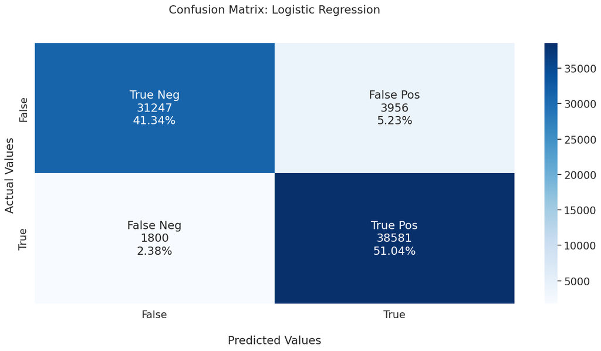

```
AUC = 0.922
```

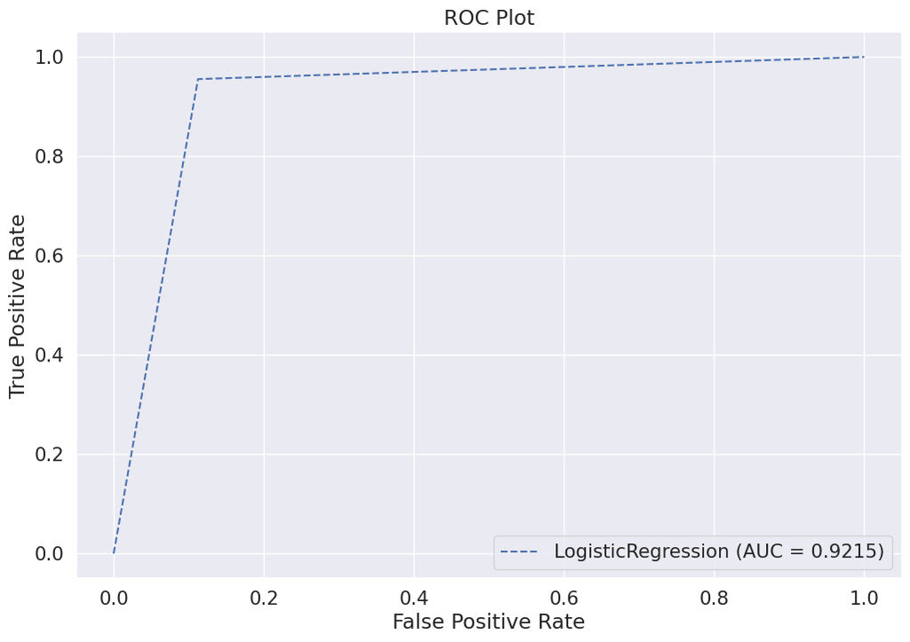

```python
# Initialize model
model1 = LogisticRegression(solver='lbfgs', max_iter=2)

# ---------------- Training time ----------------
start_train = time.time()
model1.fit(X_train, y_train)
end_train = time.time()
training_time = end_train - start_train

# ---------------- Testing time ----------------
start_test = time.time()
predictions1 = model1.predict(X_test)
end_test = time.time()
testing_time = end_test - start_test

print(f" Training Time: {training_time:.4f} seconds")
print(f" Testing Time: {testing_time:.4f} seconds")

# Accuracy
print('Accuracy :', accuracy_score(y_test, predictions1))
print("Train accuracy ={:.2f}%".format(model1.score(X_train, y_train)*100))
print("Test accuracy ={:.2f}%".format(model1.score(X_test,y_test)*100))

# Predict test dataset
y_pred_log = model1.predict(X_test)

# Confusion Matrix
print(confusion_matrix(y_test,y_pred_log))
print(classification_report(y_test, y_pred_log))
print(F'Accuracy:',accuracy_score(y_test, y_pred_log))
print(F'Precision:', precision_score(y_test, y_pred_log))
print(F'Recall:', recall_score(y_test, y_pred_log))
print(F'F1 Score:', f1_score(y_test, y_pred_log,average="micro"))
print(F'MCC:', matthews_corrcoef(y_test, y_pred_log))
print('*******************************************')

# Confusion matrix visualization
conf_matrix = confusion_matrix(y_test, y_pred_log)
group_names = ['True Neg','False Pos','False Neg','True Pos']
group_counts = ["{0:0.0f}".format(value) for value in conf_matrix.flatten()]
group_percentages = ["{0:.2%}".format(value) for value in conf_matrix.flatten()/np.sum(conf_matrix)]
labels = [f"{v1}\n{v2}\n{v3}" for v1, v2, v3 in zip(group_names,group_counts,group_percentages)]
labels = np.asarray(labels).reshape(2,2)

plt.figure(figsize=(16,7))
sns.set(font_scale=1.4)
ax = sns.heatmap(conf_matrix, annot=labels, fmt='', cmap='Blues')
ax.set_title('Confusion Matrix: Logistic Regression\n\n')
ax.set_xlabel('\nPredicted Values')
ax.set_ylabel('Actual Values ')
ax.xaxis.set_ticklabels(['False','True'])
ax.yaxis.set_ticklabels(['False','True'])
plt.show()

print('*******************************************')

# ROC Curve & AUC
lr_auc = roc_auc_score(y_test, predictions1)
print('AUC = %.3f' % (lr_auc))
lr_fpr, lr_tpr, _ = roc_curve(y_test, predictions1)

plt.figure(figsize=(12, 8))
plt.plot(lr_fpr, lr_tpr, linestyle='--', label='LogisticRegression (AUC = %0.4f)' % lr_auc)
plt.title('ROC Plot')
plt.xlabel('False Positive Rate')
plt.ylabel('True Positive Rate')
plt.legend()
plt.show()
```

```
 Training Time: 0.1360 seconds
 Testing Time: 0.0437 seconds
Accuracy : 0.9004948137171889
Train accuracy =89.94%
Test accuracy =90.05%
[[32786  2417]
 [ 5104 35277]]
              precision    recall  f1-score   support

           0       0.87      0.93      0.90     35203
           1       0.94      0.87      0.90     40381

    accuracy                           0.90     75584
   macro avg       0.90      0.90      0.90     75584
weighted avg       0.90      0.90      0.90     75584

Accuracy: 0.9004948137171889
Precision: 0.9358783891335491
Recall: 0.8736039226368837
F1 Score: 0.900494813717189
MCC: 0.8030566167190828
```

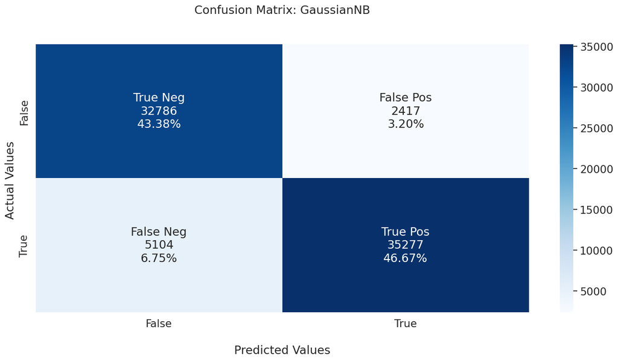

```
AUC = 0.902
```

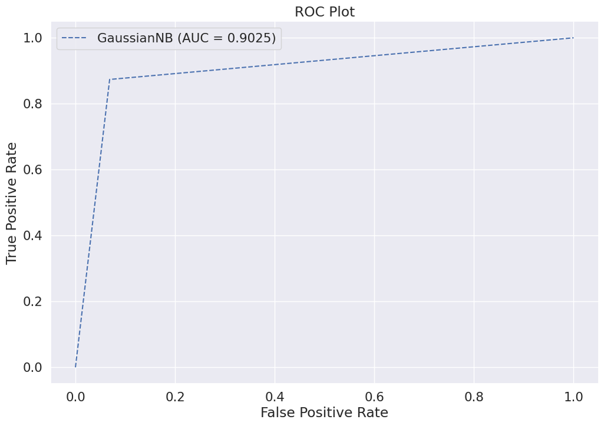

```python
# Initialize model
model2 = GaussianNB(priors=None, var_smoothing=1e-09)

# ---------------- Training time ----------------
start_train = time.time()
model2.fit(X_train, y_train)
end_train = time.time()
training_time = end_train - start_train

# ---------------- Testing time ----------------
start_test = time.time()
predictions2 = model2.predict(X_test)
end_test = time.time()
testing_time = end_test - start_test

print(f" Training Time: {training_time:.4f} seconds")
print(f" Testing Time: {testing_time:.4f} seconds")

# Accuracy
print('Accuracy :', accuracy_score(y_test, predictions2))
print("Train accuracy ={:.2f}%".format(model2.score(X_train, y_train)*100))
print("Test accuracy ={:.2f}%".format(model2.score(X_test,y_test)*100))

# Predict test dataset
y_pred_NB = model2.predict(X_test)

# Confusion Matrix
print(confusion_matrix(y_test,y_pred_NB))
print(classification_report(y_test, y_pred_NB))
print(F'Accuracy:',accuracy_score(y_test, y_pred_NB))
print(F'Precision:', precision_score(y_test, y_pred_NB))
print(F'Recall:', recall_score(y_test, y_pred_NB))
print(F'F1 Score:', f1_score(y_test, y_pred_NB,average="micro"))
print(F'MCC:', matthews_corrcoef(y_test,y_pred_NB))
print('*******************************************')

# Confusion Matrix Visualization
conf_matrix = confusion_matrix(y_test, y_pred_NB)
group_names = ['True Neg','False Pos','False Neg','True Pos']
group_counts = ["{0:0.0f}".format(value) for value in conf_matrix.flatten()]
group_percentages = ["{0:.2%}".format(value) for value in conf_matrix.flatten()/np.sum(conf_matrix)]
labels = [f"{v1}\n{v2}\n{v3}" for v1, v2, v3 in zip(group_names,group_counts,group_percentages)]
labels = np.asarray(labels).reshape(2,2)

plt.figure(figsize=(16,7))
sns.set(font_scale=1.4)
ax = sns.heatmap(conf_matrix, annot=labels, fmt='', cmap='Blues')
ax.set_title('Confusion Matrix: GaussianNB\n\n')
ax.set_xlabel('\nPredicted Values')
ax.set_ylabel('Actual Values ')
ax.xaxis.set_ticklabels(['False','True'])
ax.yaxis.set_ticklabels(['False','True'])
plt.show()

print('*******************************************')

# ROC Curve & AUC
NB_auc = roc_auc_score(y_test, predictions2)
print('AUC = %.3f' % (NB_auc))
NB_fpr, NB_tpr, _ = roc_curve(y_test, predictions2)

plt.figure(figsize=(12, 8))
plt.plot(NB_fpr, NB_tpr, linestyle='--', label='GaussianNB (AUC = %0.4f)' % NB_auc)
plt.title('ROC Plot')
plt.xlabel('False Positive Rate')
plt.ylabel('True Positive Rate')
plt.legend()
plt.show()
```

```
Training Time: 0.2821 seconds
Testing Time: 0.0046 seconds
Accuracy : 0.9777995342929721
Train accuracy =97.87%
Test accuracy =97.78%
[[34779   424]
 [ 1254 39127]]
              precision    recall  f1-score   support

           0       0.97      0.99      0.98     35203
           1       0.99      0.97      0.98     40381

    accuracy                           0.98     75584
   macro avg       0.98      0.98      0.98     75584
weighted avg       0.98      0.98      0.98     75584

Accuracy: 0.9777995342929721
Precision: 0.9780639726647024
Recall: 0.9777995342929721
F1 Score: 0.9777995342929721
MCC: 0.9556890297831179
```

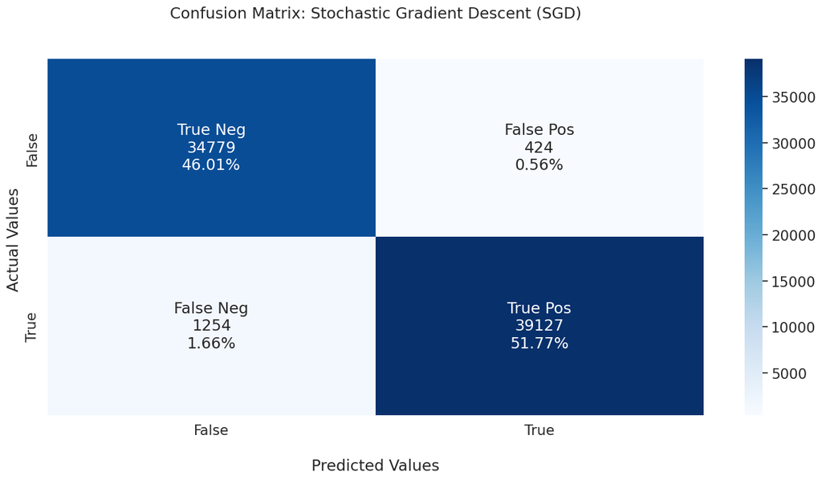

```
AUC = 0.978
```

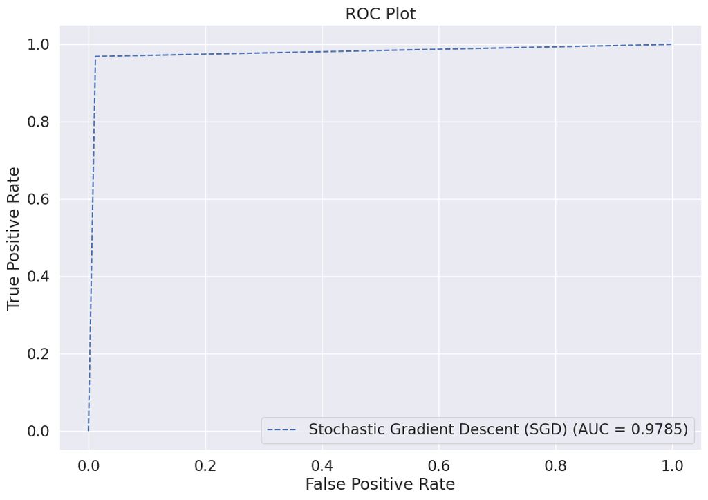

```python
# Initialize model
model3 = SGDClassifier(alpha=0.01)

# ---------------- Training time ----------------
start_train = time.time()
model3.fit(X_train, y_train)
end_train = time.time()
training_time = end_train - start_train

# ---------------- Testing time ----------------
start_test = time.time()
predictions3 = model3.predict(X_test)
end_test = time.time()
testing_time = end_test - start_test

print(f"Training Time: {training_time:.4f} seconds")
print(f"Testing Time: {testing_time:.4f} seconds")

# Accuracy
print('Accuracy :', accuracy_score(y_test, predictions3))
print("Train accuracy ={:.2f}%".format(model3.score(X_train, y_train)*100))
print("Test accuracy ={:.2f}%".format(model3.score(X_test, y_test)*100))

# Predict test dataset
y_pred_SGDC = model3.predict(X_test)

# Confusion Matrix
print(confusion_matrix(y_test, y_pred_SGDC))
print(classification_report(y_test, y_pred_SGDC))
print(F'Accuracy:', accuracy_score(y_test, y_pred_SGDC))
print(F'Precision:', precision_score(y_test, y_pred_SGDC, average="weighted"))
print(F'Recall:', recall_score(y_test, y_pred_SGDC, average="weighted"))
print(F'F1 Score:', f1_score(y_test, y_pred_SGDC, average="micro"))
print(F'MCC:', matthews_corrcoef(y_test, y_pred_SGDC))
print('*******************************************')

# Confusion Matrix Visualization
conf_matrix = confusion_matrix(y_test, y_pred_SGDC)
group_names = ['True Neg','False Pos','False Neg','True Pos']
group_counts = ["{0:0.0f}".format(value) for value in conf_matrix.flatten()]
group_percentages = ["{0:.2%}".format(value) for value in conf_matrix.flatten()/np.sum(conf_matrix)]
labels = [f"{v1}\n{v2}\n{v3}" for v1, v2, v3 in zip(group_names, group_counts, group_percentages)]
labels = np.asarray(labels).reshape(2,2)

plt.figure(figsize=(16,7))
sns.set(font_scale=1.4)
ax = sns.heatmap(conf_matrix, annot=labels, fmt='', cmap='Blues')
ax.set_title('Confusion Matrix: Stochastic Gradient Descent (SGD)\n\n')
ax.set_xlabel('\nPredicted Values')
ax.set_ylabel('Actual Values ')
ax.xaxis.set_ticklabels(['False','True'])
ax.yaxis.set_ticklabels(['False','True'])
plt.show()

print('*******************************************')

# ROC Curve & AUC
SGD_auc = roc_auc_score(y_test, predictions3)
print('AUC = %.3f' % (SGD_auc))
SGD_fpr, SGD_tpr, _ = roc_curve(y_test, predictions3)

plt.figure(figsize=(12, 8))
plt.plot(SGD_fpr, SGD_tpr, linestyle='--',
         label='Stochastic Gradient Descent (SGD) (AUC = %0.4f)' % SGD_auc)
plt.title('ROC Plot')
plt.xlabel('False Positive Rate')
plt.ylabel('True Positive Rate')
plt.legend()
plt.show()
```

```
Training Time: 0.6691 seconds
Testing Time: 0.0093 seconds
Accuracy : 0.9699671888230313
Train accuracy =97.10%
Test accuracy =97.00%
[[34275   928]
 [ 1342 39039]]
              precision    recall  f1-score   support

           0       0.96      0.97      0.97     35203
           1       0.98      0.97      0.97     40381

    accuracy                           0.97     75584
   macro avg       0.97      0.97      0.97     75584
weighted avg       0.97      0.97      0.97     75584

Accuracy: 0.9699671888230313
Precision: 0.976780844196462
Recall: 0.9667665486243531
F1 Score: 0.9717478966495744
MCC: 0.9397534574653804
```

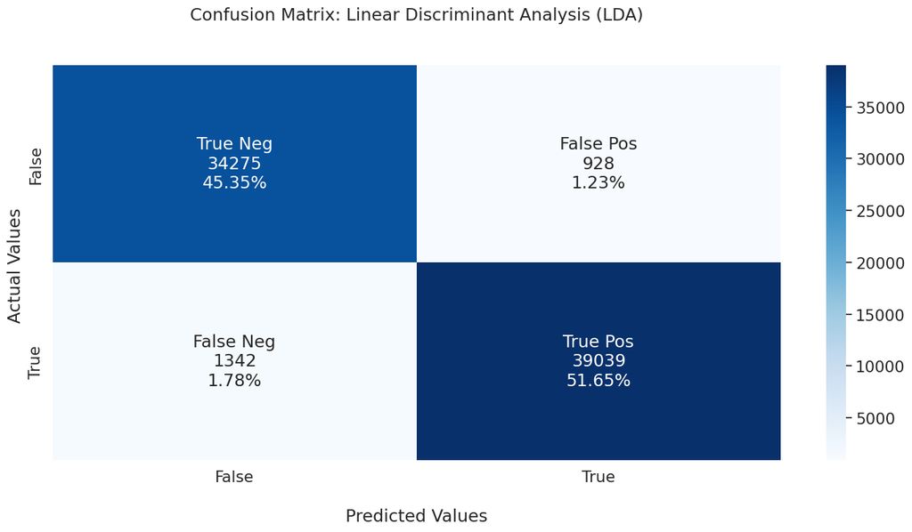

```
AUC = 0.970
```

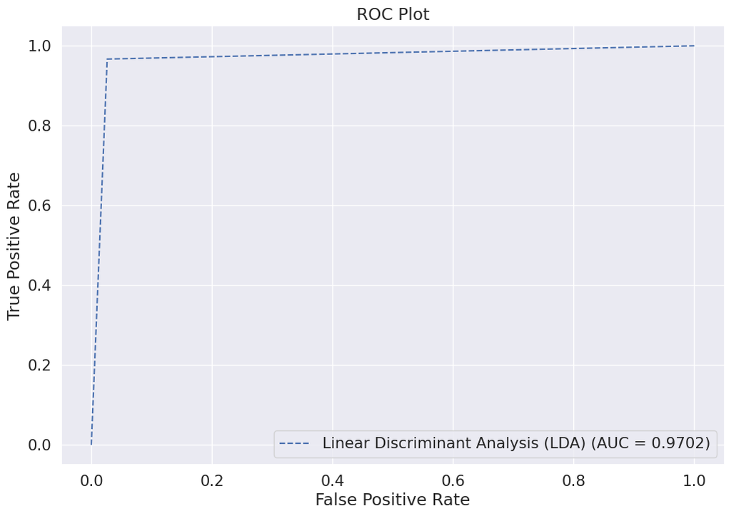

```python
# Initialize model
model4 = LinearDiscriminantAnalysis()

# ---------------- Training time ----------------
start_train = time.time()
model4.fit(X_train, y_train)
end_train = time.time()
training_time = end_train - start_train

# ---------------- Testing time ----------------
start_test = time.time()
predictions4 = model4.predict(X_test)
end_test = time.time()
testing_time = end_test - start_test

print(f"Training Time: {training_time:.4f} seconds")
print(f"Testing Time: {testing_time:.4f} seconds")

# Accuracy
print('Accuracy :', accuracy_score(y_test, predictions4))
print("Train accuracy ={:.2f}%".format(model4.score(X_train, y_train)*100))
print("Test accuracy ={:.2f}%".format(model4.score(X_test, y_test)*100))

# Predict test dataset
y_pred_LDA = model4.predict(X_test)

# Confusion Matrix & Report
print(confusion_matrix(y_test, y_pred_LDA))
print(classification_report(y_test, y_pred_LDA))
print(F'Accuracy:', accuracy_score(y_test, y_pred_LDA))
print(F'Precision:', precision_score(y_test, y_pred_LDA))
print(F'Recall:', recall_score(y_test, y_pred_LDA))
print(F'F1 Score:', f1_score(y_test, y_pred_LDA))
print(F'MCC:', matthews_corrcoef(y_test, y_pred_LDA))
print('*******************************************')

# Confusion Matrix Visualization
conf_matrix = confusion_matrix(y_test, y_pred_LDA)
group_names = ['True Neg','False Pos','False Neg','True Pos']
group_counts = ["{0:0.0f}".format(value) for value in conf_matrix.flatten()]
group_percentages = ["{0:.2%}".format(value) for value in conf_matrix.flatten()/np.sum(conf_matrix)]
labels = [f"{v1}\n{v2}\n{v3}" for v1, v2, v3 in zip(group_names, group_counts, group_percentages)]
labels = np.asarray(labels).reshape(2,2)

plt.figure(figsize=(16,7))
sns.set(font_scale=1.4)
ax = sns.heatmap(conf_matrix, annot=labels, fmt='', cmap='Blues')
ax.set_title('Confusion Matrix: Linear Discriminant Analysis (LDA)\n\n')
ax.set_xlabel('\nPredicted Values')
ax.set_ylabel('Actual Values ')
ax.xaxis.set_ticklabels(['False','True'])
ax.yaxis.set_ticklabels(['False','True'])
plt.show()

print('*******************************************')

# ROC Curve & AUC
LDA_auc = roc_auc_score(y_test, predictions4)
print('AUC = %.3f' % (LDA_auc))
LDA_fpr, LDA_tpr, _ = roc_curve(y_test, predictions4)

plt.figure(figsize=(12, 8))
plt.plot(LDA_fpr, LDA_tpr, linestyle='--',
         label='Linear Discriminant Analysis (LDA) (AUC = %0.4f)' % LDA_auc)
plt.title('ROC Plot')
plt.xlabel('False Positive Rate')
plt.ylabel('True Positive Rate')
plt.legend()
plt.show()
```

```
 Training time: 0.0427 seconds
Testing time: 31.6791 seconds
Accuracy : 0.9990077265029635
Train accuracy =99.94%
Test accuracy =99.90%
[[35162    41]
 [   34 40347]]
              precision    recall  f1-score   support

           0       1.00      1.00      1.00     35203
           1       1.00      1.00      1.00     40381

    accuracy                           1.00     75584
   macro avg       1.00      1.00      1.00     75584
weighted avg       1.00      1.00      1.00     75584

Accuracy: 0.9990077265029635
Precision: 0.9989848469842527
Recall: 0.9991580198608256
F1 Score: 0.9990714259183597
MCC: 0.9980060871756573
```

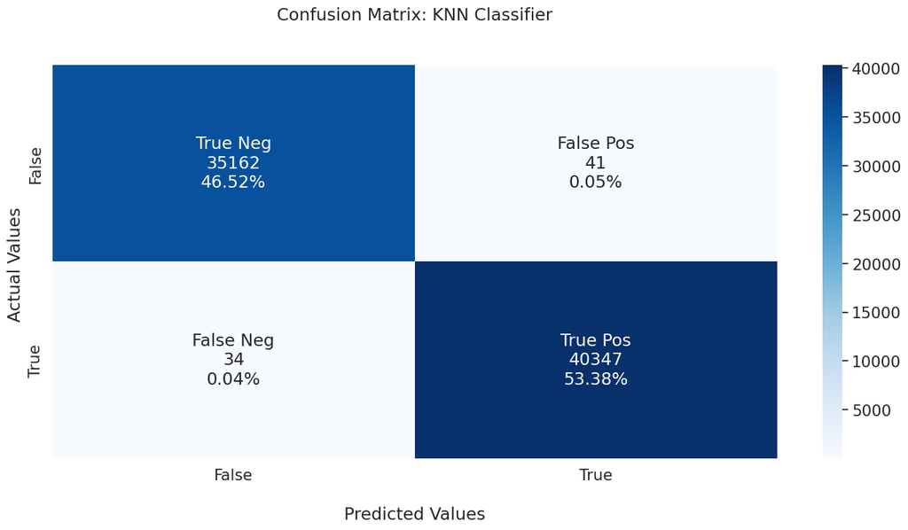

```
AUC = 0.999
```

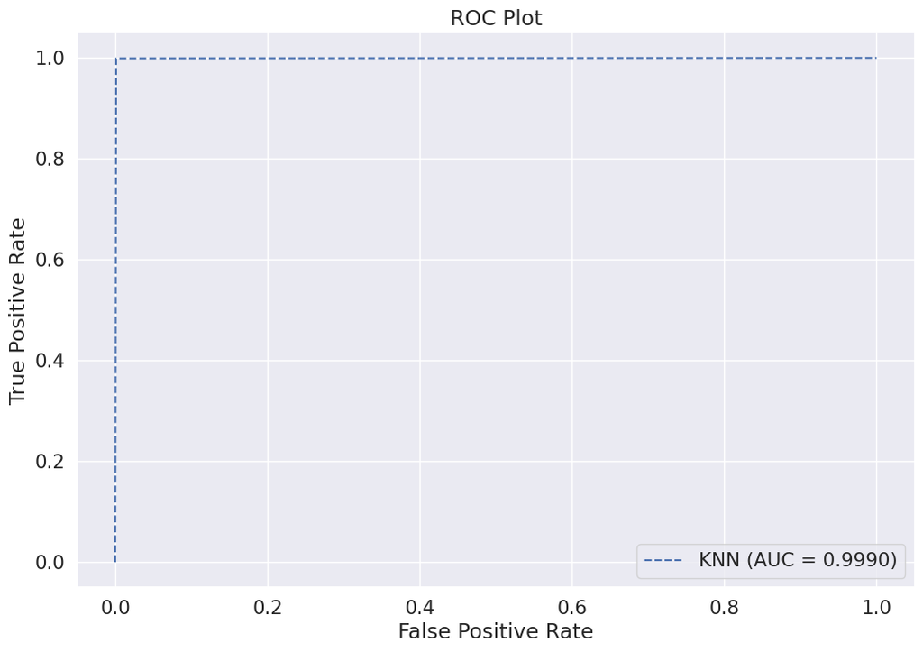

```python
# Define KNN model
model_knn = KNeighborsClassifier(n_neighbors=5, leaf_size=2, weights='uniform')

# ---------------- Train time ----------------
start_train = time.time()
model_knn.fit(X_train, y_train)
end_train = time.time()
train_time = end_train - start_train
print(f" Training time: {train_time:.4f} seconds")

# ---------------- Test time ----------------
start_test = time.time()
predictions_knn = model_knn.predict(X_test)
end_test = time.time()
test_time = end_test - start_test
print(f"Testing time: {test_time:.4f} seconds")

# Accuracy
print('Accuracy :', accuracy_score(y_test, predictions_knn))
print("Train accuracy ={:.2f}%".format(model_knn.score(X_train, y_train) * 100))
print("Test accuracy ={:.2f}%".format(model_knn.score(X_test, y_test) * 100))

# Confusion matrix
conf_matrix = confusion_matrix(y_test, predictions_knn)
print(conf_matrix)

# Classification report
print(classification_report(y_test, predictions_knn))

# Performance metrics
print(f'Accuracy: {accuracy_score(y_test, predictions_knn)}')
print(f'Precision: {precision_score(y_test, predictions_knn)}')
print(f'Recall: {recall_score(y_test, predictions_knn)}')
print(f'F1 Score: {f1_score(y_test, predictions_knn)}')
print(f'MCC: {matthews_corrcoef(y_test, predictions_knn)}')
print('*******************************************')

# Confusion matrix visualization
plt.figure(figsize=(16,7))
sns.set(font_scale=1.4)

group_names = ['True Neg','False Pos','False Neg','True Pos']
group_counts = ["{0:0.0f}".format(value) for value in conf_matrix.flatten()]
group_percentages = ["{0:.2%}".format(value) for value in conf_matrix.flatten()/np.sum(conf_matrix)]

labels = [f"{v1}\n{v2}\n{v3}" for v1, v2, v3 in zip(group_names, group_counts, group_percentages)]
labels = np.asarray(labels).reshape(2,2)

ax = sns.heatmap(conf_matrix, annot=labels, fmt='', cmap='Blues')

ax.set_title('Confusion Matrix: KNN Classifier\n\n')
ax.set_xlabel('\nPredicted Values')
ax.set_ylabel('Actual Values ')
ax.xaxis.set_ticklabels(['False','True'])
ax.yaxis.set_ticklabels(['False','True'])

plt.show()
print('*******************************************')

# ROC Curve
knn_auc = roc_auc_score(y_test, predictions_knn)
print('AUC = %.3f' % (knn_auc))
knn_fpr, knn_tpr, _ = roc_curve(y_test, predictions_knn)

plt.figure(figsize=(12, 8))
plt.plot(knn_fpr, knn_tpr, linestyle='--', label='KNN (AUC = %0.4f)' % knn_auc)

plt.title('ROC Plot')
plt.xlabel('False Positive Rate')
plt.ylabel('True Positive Rate')
plt.legend()
plt.show()
```

```python
#pip install shap
```

```
Best Hyperparameters from Bee Algorithm:
  n_neighbors : 1
  metric      : manhattan
⏱ Training Time: 0.0441 seconds
⏱ Testing Time: 301.8811 seconds
⏱ Total Time (Training + Testing): 301.9253 seconds

Model Evaluation:
Training Accuracy : 1.0000
Testing Accuracy  : 0.9998
Precision          : 0.9998
Recall             : 0.9998
F1 Score           : 0.9998
Matthews Corrcoef  : 0.9995

Classification Report:
               precision    recall  f1-score   support

           0       1.00      1.00      1.00     35203
           1       1.00      1.00      1.00     40381

    accuracy                           1.00     75584
   macro avg       1.00      1.00      1.00     75584
weighted avg       1.00      1.00      1.00     75584
```

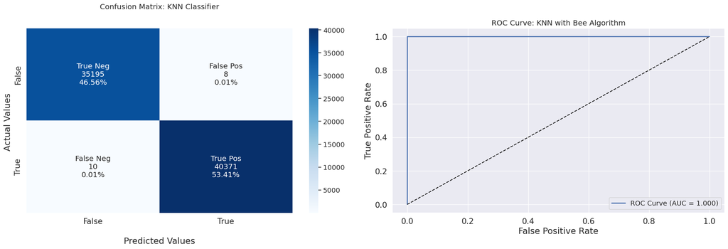

```
Confusion Matrix:
[[35195     8]
 [   10 40371]]

AUC Score: 1.000
```

```python
# Define search space for KNN
bounds = (
    np.array([1, 0]),      # Lower bounds
    np.array([30, 3])      # Upper bounds
)
cv = StratifiedKFold(n_splits=5, shuffle=True, random_state=44)

# -----------------------------------------------------------
# Objective Function
# -----------------------------------------------------------
def objective_function(params):
    losses = []
    for p in params:
        n_neighbors = int(p[0])
        metric_index = int(round(p[1]))
        metric_list = ['euclidean', 'manhattan', 'chebyshev', 'minkowski']
        metric = metric_list[metric_index]

        clf = KNeighborsClassifier(
            n_neighbors=n_neighbors,
            metric=metric
        )

        score = cross_val_score(clf, X_train, y_train, cv=cv, scoring='accuracy').mean()
        losses.append(1 - score)  # minimize loss
    return np.array(losses)

# -----------------------------------------------------------
# Bee Algorithm
# -----------------------------------------------------------
class BeeOptimizer:
    def __init__(self, n_bees, n_elite, n_best, patch_size, bounds, max_iter):
        self.n_bees = n_bees
        self.n_elite = n_elite
        self.n_best = n_best
        self.patch_size = patch_size
        self.bounds = bounds
        self.max_iter = max_iter

    def optimize(self):
        population = np.random.uniform(self.bounds[0], self.bounds[1], (self.n_bees, len(self.bounds[0])))
        best_solution = None
        best_fitness = float('inf')

        for iteration in range(self.max_iter):
            fitness = objective_function(population)

            sorted_indices = np.argsort(fitness)
            population = population[sorted_indices]
            fitness = fitness[sorted_indices]

            if fitness[0] < best_fitness:
                best_fitness = fitness[0]
                best_solution = population[0]

            new_population = []
            for i in range(self.n_elite):
                for _ in range(self.n_best):
                    candidate = population[i] + np.random.uniform(-self.patch_size, self.patch_size, len(self.bounds[0]))
                    candidate = np.clip(candidate, self.bounds[0], self.bounds[1])
                    new_population.append(candidate)

            for i in range(self.n_elite, self.n_best):
                candidate = population[i] + np.random.uniform(-self.patch_size, self.patch_size, len(self.bounds[0]))
                candidate = np.clip(candidate, self.bounds[0], self.bounds[1])
                new_population.append(candidate)

            while len(new_population) < self.n_bees:
                candidate = np.random.uniform(self.bounds[0], self.bounds[1], len(self.bounds[0]))
                new_population.append(candidate)

            population = np.array(new_population)

        return best_solution, 1 - best_fitness

# -----------------------------------------------------------
# Run Bee Algorithm
# -----------------------------------------------------------
optimizer = BeeOptimizer(n_bees=5, n_elite=5, n_best=5, patch_size=2, bounds=bounds, max_iter=5)
best_params, best_acc = optimizer.optimize()

best_n_neighbors = int(best_params[0])
best_metric = ['euclidean', 'manhattan', 'chebyshev', 'minkowski'][int(round(best_params[1]))]

print("Best Hyperparameters from Bee Algorithm:")
print(f"  n_neighbors : {best_n_neighbors}")
print(f"  metric      : {best_metric}")

# -----------------------------------------------------------
# Training + Testing with Time Measurement
# -----------------------------------------------------------
model_knn = KNeighborsClassifier(
    n_neighbors=best_n_neighbors,
    metric=best_metric
)

# Training
start_train = time.time()
model_knn.fit(X_train, y_train)
end_train = time.time()
train_time = end_train - start_train
print(f"⏱ Training Time: {train_time:.4f} seconds")

# Testing
start_test = time.time()
predictions_knn = model_knn.predict(X_test)
end_test = time.time()
test_time = end_test - start_test
print(f"⏱ Testing Time: {test_time:.4f} seconds")

# Total
print(f"⏱ Total Time (Training + Testing): {train_time + test_time:.4f} seconds")

# -----------------------------------------------------------
# Metrics
# -----------------------------------------------------------
prob_knn = model_knn.predict_proba(X_test)[:, 1] if len(np.unique(y_test)) == 2 else None

train_accuracy = accuracy_score(y_train, model_knn.predict(X_train))
test_accuracy = accuracy_score(y_test, predictions_knn)
precision = precision_score(y_test, predictions_knn, average='macro')
recall = recall_score(y_test, predictions_knn, average='macro')
f1 = f1_score(y_test, predictions_knn, average='macro')
mcc = matthews_corrcoef(y_test, predictions_knn)
report = classification_report(y_test, predictions_knn)

print("\nModel Evaluation:")
print(f"Training Accuracy : {train_accuracy:.4f}")
print(f"Testing Accuracy  : {test_accuracy:.4f}")
print(f"Precision          : {precision:.4f}")
print(f"Recall             : {recall:.4f}")
print(f"F1 Score           : {f1:.4f}")
print(f"Matthews Corrcoef  : {mcc:.4f}")
print("\nClassification Report:\n", report)

# -----------------------------------------------------------
# Confusion Matrix & ROC
# -----------------------------------------------------------
fig, (ax1, ax2) = plt.subplots(1, 2, figsize=(20, 7))
sns.set(font_scale=1.2)

conf_matrix = confusion_matrix(y_test, predictions_knn)

group_names = ['True Neg','False Pos','False Neg','True Pos']
group_counts = ["{0:0.0f}".format(value) for value in conf_matrix.flatten()]
group_percentages = ["{0:.2%}".format(value) for value in conf_matrix.flatten()/np.sum(conf_matrix)]
labels = [f"{v1}\n{v2}\n{v3}" for v1, v2, v3 in zip(group_names, group_counts, group_percentages)]
labels = np.asarray(labels).reshape(2,2)

sns.heatmap(conf_matrix, annot=labels, fmt='', cmap='Blues', ax=ax1)
ax1.set_title('Confusion Matrix: KNN Classifier\n\n')
ax1.set_xlabel('\nPredicted Values')
ax1.set_ylabel('Actual Values ')
ax1.xaxis.set_ticklabels(['False','True'])
ax1.yaxis.set_ticklabels(['False','True'])

# ROC curve
if prob_knn is not None:
    auc = roc_auc_score(y_test, prob_knn)
    fpr, tpr, _ = roc_curve(y_test, prob_knn)
    ax2.plot(fpr, tpr, label=f'ROC Curve (AUC = {auc:.3f})', linewidth=2)
    ax2.plot([0, 1], [0, 1], 'k--')
    ax2.set_xlabel('False Positive Rate')
    ax2.set_ylabel('True Positive Rate')
    ax2.set_title('ROC Curve: KNN with Bee Algorithm')
    ax2.legend(loc='lower right')
    ax2.grid(True)

plt.tight_layout()
plt.show()

print("Confusion Matrix:")
print(conf_matrix)
if prob_knn is not None:
    print(f"\nAUC Score: {auc:.3f}")
```

```python
#pip install lime
```

```python
import lime
```

```python
# -----------------------------------------------------------
# LIME Explanation for KNN with Bee Optimization
# -----------------------------------------------------------
import lime
import lime.lime_tabular

# Initialize LIME explainer
explainer = lime.lime_tabular.LimeTabularExplainer(
    training_data=X_train,
    feature_names=X_train.columns if hasattr(X_train, 'columns') else [f"f{i}" for i in range(X_train.shape[1])],
    class_names=np.unique(y_train).astype(str),
    mode='classification'
)

# Select one instance from the test set
i = 0
instance = X_test[i]

if len(instance.shape) == 1:  # if 1D array, reshape
    instance = instance.reshape(1, -1)

# Generate explanation
exp = explainer.explain_instance(
    data_row=instance[0],
    predict_fn=model_knn.predict_proba,
    num_features=10  # top 10 features
)

# Show explanation in console
print("\nLIME Explanation for test instance 0:")
print(exp.as_list())

# Show explanation in notebook (requires Jupyter)
exp.show_in_notebook(show_table=True, show_all=False)

# Save explanation to HTML file
exp.save_to_file("lime_knn_bee.html")
print("\nLIME explanation saved as 'lime_knn_bee.html'")
```

[output not shown]

```
LIME explanation saved as 'lime_knn_bee.html'
```

# LSTM-Model

[output not shown]

```
Model: "LSTM-Model"
```

```
┏━━━━━━━━━━━━━━━━━━━━━━━━━━━━━━━━━┳━━━━━━━━━━━━━━━━━━━━━━━━┳━━━━━━━━━━━━━━━┓
┃ Layer (type)                    ┃ Output Shape           ┃       Param # ┃
┡━━━━━━━━━━━━━━━━━━━━━━━━━━━━━━━━━╇━━━━━━━━━━━━━━━━━━━━━━━━╇━━━━━━━━━━━━━━━┩
│ lstm (LSTM)                     │ (None, 42, 128)        │        66,560 │
├─────────────────────────────────┼────────────────────────┼───────────────┤
│ lstm_1 (LSTM)                   │ (None, 42, 64)         │        49,408 │
├─────────────────────────────────┼────────────────────────┼───────────────┤
│ dropout (Dropout)               │ (None, 42, 64)         │             0 │
├─────────────────────────────────┼────────────────────────┼───────────────┤
│ lstm_2 (LSTM)                   │ (None, 32)             │        12,416 │
├─────────────────────────────────┼────────────────────────┼───────────────┤
│ flatten (Flatten)               │ (None, 32)             │             0 │
├─────────────────────────────────┼────────────────────────┼───────────────┤
│ dense (Dense)                   │ (None, 32)             │         1,056 │
├─────────────────────────────────┼────────────────────────┼───────────────┤
│ dropout_1 (Dropout)             │ (None, 32)             │             0 │
├─────────────────────────────────┼────────────────────────┼───────────────┤
│ dense_1 (Dense)                 │ (None, 1)              │            33 │
├─────────────────────────────────┼────────────────────────┼───────────────┤
│ activation (Activation)         │ (None, 1)              │             0 │
└─────────────────────────────────┴────────────────────────┴───────────────┘
```

```
 Total params: 129,473 (505.75 KB)
```

```
 Trainable params: 129,473 (505.75 KB)
```

```
 Non-trainable params: 0 (0.00 B)
```

```
I0000 00:00:1758318015.123685      70 cuda_dnn.cc:529] Loaded cuDNN version 90300
```

```
689/689 ━━━━━━━━━━━━━━━━━━━━ 17s 14ms/step - accuracy: 0.9086 - loss: 0.2349 - val_accuracy: 0.9840 - val_loss: 0.0548
689/689 ━━━━━━━━━━━━━━━━━━━━ 9s 13ms/step - accuracy: 0.9865 - loss: 0.0388 - val_accuracy: 0.9927 - val_loss: 0.0212
689/689 ━━━━━━━━━━━━━━━━━━━━ 9s 13ms/step - accuracy: 0.9913 - loss: 0.0246 - val_accuracy: 0.9910 - val_loss: 0.0239
689/689 ━━━━━━━━━━━━━━━━━━━━ 9s 13ms/step - accuracy: 0.9936 - loss: 0.0186 - val_accuracy: 0.9941 - val_loss: 0.0160
689/689 ━━━━━━━━━━━━━━━━━━━━ 9s 13ms/step - accuracy: 0.9946 - loss: 0.0153 - val_accuracy: 0.9955 - val_loss: 0.0117
689/689 ━━━━━━━━━━━━━━━━━━━━ 9s 13ms/step - accuracy: 0.9956 - loss: 0.0123 - val_accuracy: 0.9932 - val_loss: 0.0196
689/689 ━━━━━━━━━━━━━━━━━━━━ 9s 13ms/step - accuracy: 0.9957 - loss: 0.0122 - val_accuracy: 0.9962 - val_loss: 0.0105
689/689 ━━━━━━━━━━━━━━━━━━━━ 9s 13ms/step - accuracy: 0.9964 - loss: 0.0100 - val_accuracy: 0.9963 - val_loss: 0.0104
689/689 ━━━━━━━━━━━━━━━━━━━━ 9s 13ms/step - accuracy: 0.9964 - loss: 0.0097 - val_accuracy: 0.9964 - val_loss: 0.0102
689/689 ━━━━━━━━━━━━━━━━━━━━ 9s 13ms/step - accuracy: 0.9964 - loss: 0.0098 - val_accuracy: 0.9967 - val_loss: 0.0082
 Training Time: 98.7250 seconds
 Testing Time: 17.6296 seconds
 Total Time (Training + Testing): 116.3546 seconds

Test Accuracy: 0.9967
Precision: 0.9956281183619029
Recall: 0.9982169832346895
F1 Score: 0.9969208700706098
Matthews Correlation Coefficient: 0.9933828421276185
ROC AUC Score: 0.9999560284362802
Classification Report:
               precision    recall  f1-score   support

           0       1.00      0.99      1.00     35203
           1       1.00      1.00      1.00     40381

    accuracy                           1.00     75584
   macro avg       1.00      1.00      1.00     75584
weighted avg       1.00      1.00      1.00     75584
```

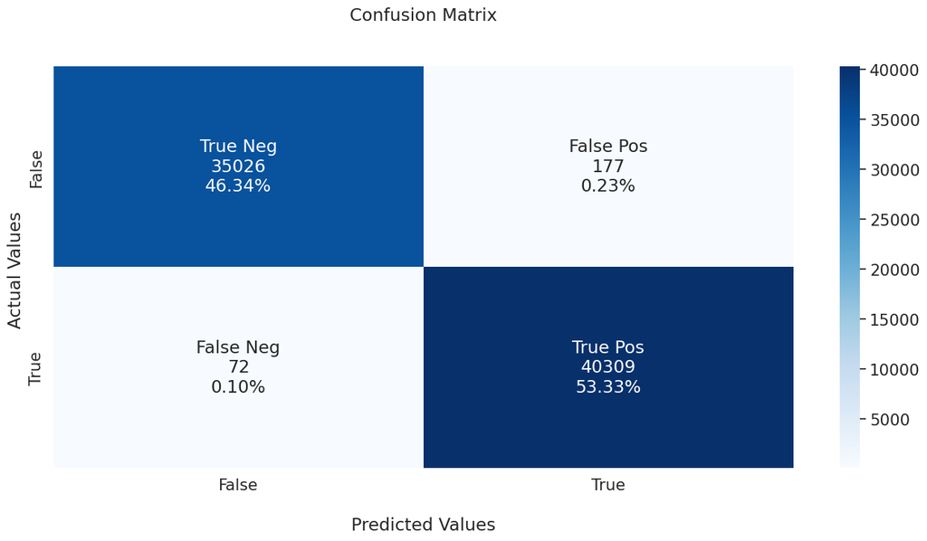

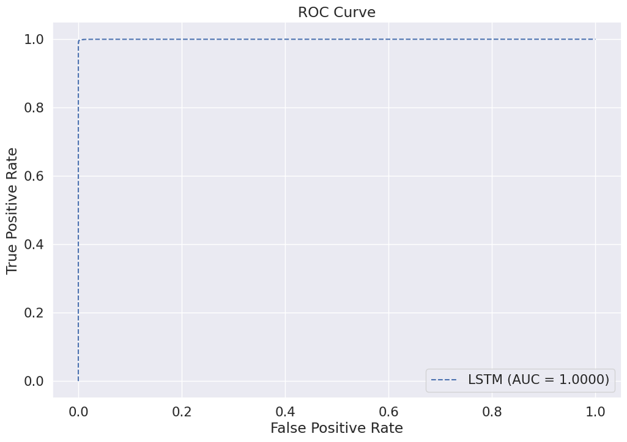

```python
# -----------------------------------------------------------
# Build Model
# -----------------------------------------------------------
model_1 = Sequential(name="LSTM-Model")
model_1.add(LSTM(units=128, input_shape=(42,1), return_sequences=True))
model_1.add(LSTM(units=64, return_sequences=True))
model_1.add(Dropout(0.01))
model_1.add(LSTM(32))
model_1.add(Flatten())
model_1.add(Dense(units=32, activation='relu'))
model_1.add(Dropout(0.01))
model_1.add(Dense(units=1))
model_1.add(Activation('sigmoid'))
model_1.summary()

# Compile
model_1.compile(loss='binary_crossentropy', optimizer='adam', metrics=['accuracy'])

# -----------------------------------------------------------
# Training with time measurement
# -----------------------------------------------------------
start_train = time.time()
history = model_1.fit(
    X_train, y_train,
    epochs=10,
    batch_size=256,
    validation_data=(X_test, y_test),
    verbose=1,
    shuffle=False
)
end_train = time.time()
train_time = end_train - start_train
print(f" Training Time: {train_time:.4f} seconds")

# -----------------------------------------------------------
# Testing with time measurement
# -----------------------------------------------------------
start_test = time.time()
loss, accuracy = model_1.evaluate(X_test, y_test, verbose=0)
y_pred_prob = model_1.predict(X_test, verbose=0)
end_test = time.time()
test_time = end_test - start_test
print(f" Testing Time: {test_time:.4f} seconds")
print(f" Total Time (Training + Testing): {train_time + test_time:.4f} seconds")

print(f"\nTest Accuracy: {accuracy:.4f}")

# -----------------------------------------------------------
# Predictions and Metrics
# -----------------------------------------------------------
y_pred = np.round(y_pred_prob).astype(int)

precision = precision_score(y_test, y_pred)
recall = recall_score(y_test, y_pred)
f1 = f1_score(y_test, y_pred)
mcc = matthews_corrcoef(y_test, y_pred)
roc_auc1 = roc_auc_score(y_test, y_pred_prob)

print(f"Precision: {precision}")
print(f"Recall: {recall}")
print(f"F1 Score: {f1}")
print(f"Matthews Correlation Coefficient: {mcc}")
print(f"ROC AUC Score: {roc_auc1}")
print("Classification Report:\n", classification_report(y_test, y_pred))

# -----------------------------------------------------------
# Confusion Matrix
# -----------------------------------------------------------
conf_matrix = confusion_matrix(y_test, y_pred)

plt.figure(figsize=(16, 7))
sns.set(font_scale=1.4)
group_names = ['True Neg', 'False Pos', 'False Neg', 'True Pos']
group_counts = ["{0:0.0f}".format(value) for value in conf_matrix.flatten()]
group_percentages = ["{0:.2%}".format(value) for value in conf_matrix.flatten()/np.sum(conf_matrix)]
labels = [f"{v1}\n{v2}\n{v3}" for v1, v2, v3 in zip(group_names, group_counts, group_percentages)]
labels = np.asarray(labels).reshape(2, 2)

ax = sns.heatmap(conf_matrix, annot=labels, fmt='', cmap='Blues')
ax.set_title('Confusion Matrix\n\n')
ax.set_xlabel('\nPredicted Values')
ax.set_ylabel('Actual Values ')
ax.xaxis.set_ticklabels(['False', 'True'])
ax.yaxis.set_ticklabels(['False', 'True'])
plt.show()

print('*******************************************')

# -----------------------------------------------------------
# ROC Curve
# -----------------------------------------------------------
fpr1, tpr1, _ = roc_curve(y_test, y_pred_prob)
plt.figure(figsize=(12, 8))
plt.plot(fpr1, tpr1, linestyle='--', label=f'LSTM (AUC = {roc_auc1:.4f})')
plt.title('ROC Curve')
plt.xlabel('False Positive Rate')
plt.ylabel('True Positive Rate')
plt.legend()
plt.show()
```

# CNN-Model

```
Model: "sequential"
```

```
┏━━━━━━━━━━━━━━━━━━━━━━━━━━━━━━━━━┳━━━━━━━━━━━━━━━━━━━━━━━━┳━━━━━━━━━━━━━━━┓
┃ Layer (type)                    ┃ Output Shape           ┃       Param # ┃
┡━━━━━━━━━━━━━━━━━━━━━━━━━━━━━━━━━╇━━━━━━━━━━━━━━━━━━━━━━━━╇━━━━━━━━━━━━━━━┩
│ conv1d (Conv1D)                 │ (None, 40, 128)        │           512 │
├─────────────────────────────────┼────────────────────────┼───────────────┤
│ average_pooling1d               │ (None, 20, 128)        │             0 │
│ (AveragePooling1D)              │                        │               │
├─────────────────────────────────┼────────────────────────┼───────────────┤
│ dropout_2 (Dropout)             │ (None, 20, 128)        │             0 │
├─────────────────────────────────┼────────────────────────┼───────────────┤
│ flatten_1 (Flatten)             │ (None, 2560)           │             0 │
├─────────────────────────────────┼────────────────────────┼───────────────┤
│ dense_2 (Dense)                 │ (None, 128)            │       327,808 │
├─────────────────────────────────┼────────────────────────┼───────────────┤
│ dropout_3 (Dropout)             │ (None, 128)            │             0 │
├─────────────────────────────────┼────────────────────────┼───────────────┤
│ dense_3 (Dense)                 │ (None, 1)              │           129 │
├─────────────────────────────────┼────────────────────────┼───────────────┤
│ activation_1 (Activation)       │ (None, 1)              │             0 │
└─────────────────────────────────┴────────────────────────┴───────────────┘
```

```
 Total params: 328,449 (1.25 MB)
```

```
 Trainable params: 328,449 (1.25 MB)
```

```
 Non-trainable params: 0 (0.00 B)
```

[output not shown]

```
 52/689 ━━━━━━━━━━━━━━━━━━━━ 1s 3ms/step - accuracy: 0.8528 - loss: 0.3523
```

```
I0000 00:00:1758318132.523615      67 device_compiler.h:188] Compiled cluster using XLA!  This line is logged at most once for the lifetime of the process.
```

```
689/689 ━━━━━━━━━━━━━━━━━━━━ 10s 7ms/step - accuracy: 0.9481 - loss: 0.1409 - val_accuracy: 0.9892 - val_loss: 0.0374
689/689 ━━━━━━━━━━━━━━━━━━━━ 3s 4ms/step - accuracy: 0.9837 - loss: 0.0478 - val_accuracy: 0.9931 - val_loss: 0.0291
689/689 ━━━━━━━━━━━━━━━━━━━━ 3s 4ms/step - accuracy: 0.9874 - loss: 0.0397 - val_accuracy: 0.9945 - val_loss: 0.0240
689/689 ━━━━━━━━━━━━━━━━━━━━ 2s 4ms/step - accuracy: 0.9891 - loss: 0.0338 - val_accuracy: 0.9946 - val_loss: 0.0205
689/689 ━━━━━━━━━━━━━━━━━━━━ 2s 4ms/step - accuracy: 0.9896 - loss: 0.0303 - val_accuracy: 0.9949 - val_loss: 0.0205
689/689 ━━━━━━━━━━━━━━━━━━━━ 3s 4ms/step - accuracy: 0.9905 - loss: 0.0296 - val_accuracy: 0.9956 - val_loss: 0.0179
689/689 ━━━━━━━━━━━━━━━━━━━━ 2s 4ms/step - accuracy: 0.9910 - loss: 0.0278 - val_accuracy: 0.9955 - val_loss: 0.0177
689/689 ━━━━━━━━━━━━━━━━━━━━ 2s 4ms/step - accuracy: 0.9914 - loss: 0.0275 - val_accuracy: 0.9953 - val_loss: 0.0151
689/689 ━━━━━━━━━━━━━━━━━━━━ 2s 4ms/step - accuracy: 0.9913 - loss: 0.0263 - val_accuracy: 0.9954 - val_loss: 0.0139
689/689 ━━━━━━━━━━━━━━━━━━━━ 3s 4ms/step - accuracy: 0.9919 - loss: 0.0245 - val_accuracy: 0.9955 - val_loss: 0.0131
Training Time: 32.51 seconds
2362/2362 ━━━━━━━━━━━━━━━━━━━━ 5s 2ms/step - accuracy: 0.9954 - loss: 0.0134
Testing Time: 4.77 seconds
Test Accuracy: 0.9955149292945862
2362/2362 ━━━━━━━━━━━━━━━━━━━━ 3s 1ms/step
Accuracy: 0.9955149237933955
Precision: 0.9988289814630257
Recall: 0.9927688764517967
F1 Score: 0.9957897090055516
Matthews Correlation Coefficient: 0.9910125736534644
ROC AUC Score: 0.9998855263471133
Classification Report:
               precision    recall  f1-score   support

           0       0.99      1.00      1.00     35203
           1       1.00      0.99      1.00     40381

    accuracy                           1.00     75584
   macro avg       1.00      1.00      1.00     75584
weighted avg       1.00      1.00      1.00     75584
```

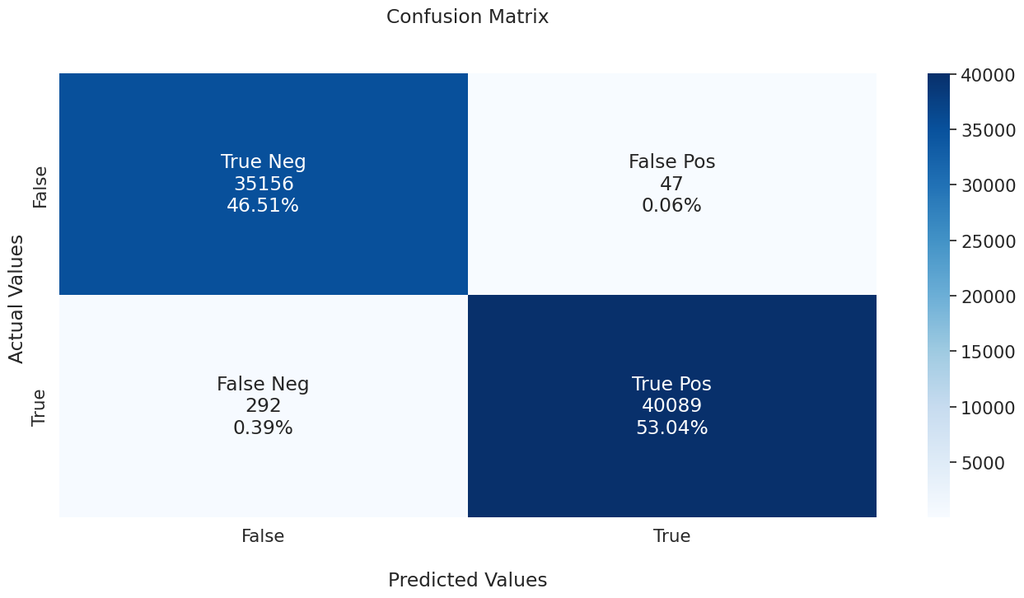

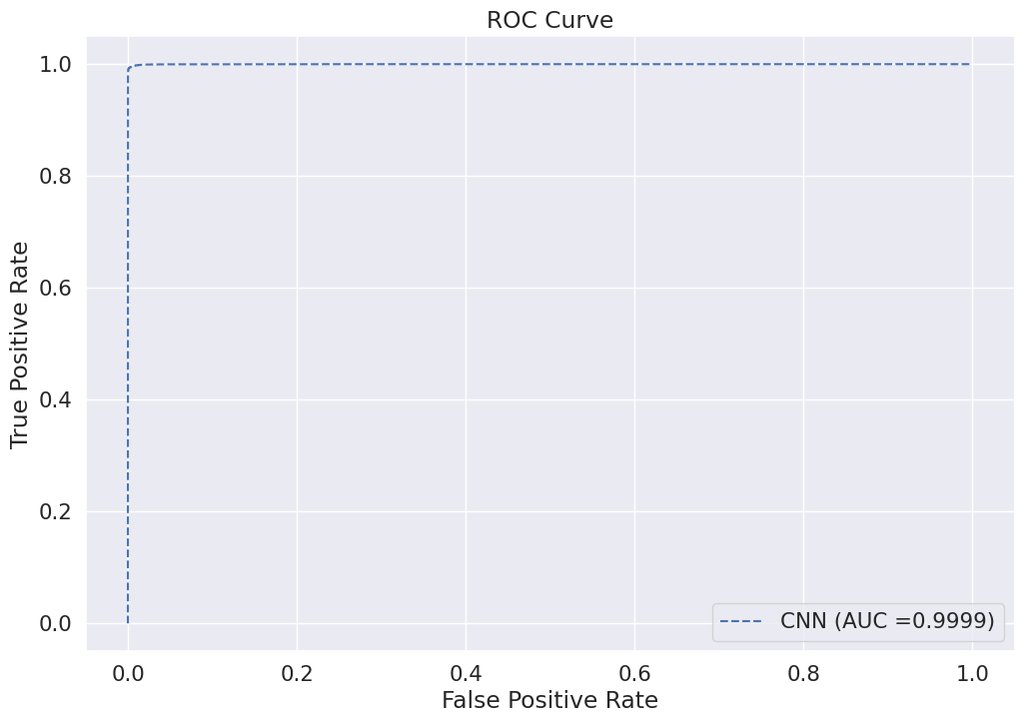

```python
model_2 = Sequential()
model_2.add(Conv1D(128, 3, activation='relu', input_shape=(42,1)))
model_2.add(AveragePooling1D(pool_size=2))
model_2.add(Dropout(0.75))
model_2.add(Flatten())
model_2.add(Dense(units = 128, activation='relu'))
model_2.add(Dropout(0.75))
model_2.add(Dense(units = 1))
model_2.add(Activation('sigmoid'))

model_2.summary()

# Compile the model
model_2.compile(loss='binary_crossentropy', optimizer='adam', metrics=['accuracy'])

# Track training time
start_train = time.time()
history = model_2.fit(
    X_train, y_train,
    epochs=10,
    batch_size=256,
    validation_data=(X_test, y_test),
    verbose=1,
    shuffle=False
)
end_train = time.time()
training_time = end_train - start_train
print(f"Training Time: {training_time:.2f} seconds")

# Track testing (evaluation) time
start_test = time.time()
loss, accuracy = model_2.evaluate(X_test, y_test)
end_test = time.time()
testing_time = end_test - start_test
print(f"Testing Time: {testing_time:.2f} seconds")

print(f"Test Accuracy: {accuracy}")

# Make predictions
y_pred_prob = model_2.predict(X_test)
y_pred = np.round(y_pred_prob).astype(int)  # Convert predictions to binary

# Calculate various metrics
accuracy = accuracy_score(y_test, y_pred)
precision = precision_score(y_test, y_pred)
recall = recall_score(y_test, y_pred)
f1 = f1_score(y_test, y_pred)
mcc = matthews_corrcoef(y_test, y_pred)
roc_auc2 = roc_auc_score(y_test, y_pred_prob)

# Print metrics
print(f"Accuracy: {accuracy}")
print(f"Precision: {precision}")
print(f"Recall: {recall}")
print(f"F1 Score: {f1}")
print(f"Matthews Correlation Coefficient: {mcc}")
print(f"ROC AUC Score: {roc_auc2}")
print("Classification Report:\n", classification_report(y_test, y_pred))

# Confusion matrix
conf_matrix = confusion_matrix(y_test, y_pred)

plt.figure(figsize=(16, 7))
sns.set(font_scale=1.4)

group_names = ['True Neg', 'False Pos', 'False Neg', 'True Pos']
group_counts = ["{0:0.0f}".format(value) for value in conf_matrix.flatten()]
group_percentages = ["{0:.2%}".format(value) for value in conf_matrix.flatten()/np.sum(conf_matrix)]

labels = [f"{v1}\n{v2}\n{v3}" for v1, v2, v3 in zip(group_names, group_counts, group_percentages)]
labels = np.asarray(labels).reshape(2, 2)

ax = sns.heatmap(conf_matrix, annot=labels, fmt='', cmap='Blues')
ax.set_title('Confusion Matrix\n\n')
ax.set_xlabel('\nPredicted Values')
ax.set_ylabel('Actual Values ')
ax.xaxis.set_ticklabels(['False', 'True'])
ax.yaxis.set_ticklabels(['False', 'True'])

plt.show()

print('*******************************************')

# ROC curve and AUC
fpr2, tpr2, _ = roc_curve(y_test, y_pred_prob)

plt.figure(figsize=(12, 8))
plt.plot(fpr2, tpr2, linestyle='--', label=f'CNN (AUC ={roc_auc2:.4f})')

plt.title('ROC Curve')
plt.xlabel('False Positive Rate')
plt.ylabel('True Positive Rate')
plt.legend()
plt.show()
```

# ANN-1-Model

```
Model: "sequential_1"
```

```
┏━━━━━━━━━━━━━━━━━━━━━━━━━━━━━━━━━┳━━━━━━━━━━━━━━━━━━━━━━━━┳━━━━━━━━━━━━━━━┓
┃ Layer (type)                    ┃ Output Shape           ┃       Param # ┃
┡━━━━━━━━━━━━━━━━━━━━━━━━━━━━━━━━━╇━━━━━━━━━━━━━━━━━━━━━━━━╇━━━━━━━━━━━━━━━┩
│ dense_4 (Dense)                 │ (None, 1024)           │        44,032 │
├─────────────────────────────────┼────────────────────────┼───────────────┤
│ dropout_4 (Dropout)             │ (None, 1024)           │             0 │
├─────────────────────────────────┼────────────────────────┼───────────────┤
│ batch_normalization             │ (None, 1024)           │         4,096 │
│ (BatchNormalization)            │                        │               │
├─────────────────────────────────┼────────────────────────┼───────────────┤
│ dense_5 (Dense)                 │ (None, 1024)           │     1,049,600 │
├─────────────────────────────────┼────────────────────────┼───────────────┤
│ dropout_5 (Dropout)             │ (None, 1024)           │             0 │
├─────────────────────────────────┼────────────────────────┼───────────────┤
│ batch_normalization_1           │ (None, 1024)           │         4,096 │
│ (BatchNormalization)            │                        │               │
├─────────────────────────────────┼────────────────────────┼───────────────┤
│ dense_6 (Dense)                 │ (None, 500)            │       512,500 │
├─────────────────────────────────┼────────────────────────┼───────────────┤
│ dropout_6 (Dropout)             │ (None, 500)            │             0 │
├─────────────────────────────────┼────────────────────────┼───────────────┤
│ batch_normalization_2           │ (None, 500)            │         2,000 │
│ (BatchNormalization)            │                        │               │
├─────────────────────────────────┼────────────────────────┼───────────────┤
│ dense_7 (Dense)                 │ (None, 250)            │       125,250 │
├─────────────────────────────────┼────────────────────────┼───────────────┤
│ dropout_7 (Dropout)             │ (None, 250)            │             0 │
├─────────────────────────────────┼────────────────────────┼───────────────┤
│ batch_normalization_3           │ (None, 250)            │         1,000 │
│ (BatchNormalization)            │                        │               │
├─────────────────────────────────┼────────────────────────┼───────────────┤
│ dense_8 (Dense)                 │ (None, 50)             │        12,550 │
├─────────────────────────────────┼────────────────────────┼───────────────┤
│ dropout_8 (Dropout)             │ (None, 50)             │             0 │
├─────────────────────────────────┼────────────────────────┼───────────────┤
│ batch_normalization_4           │ (None, 50)             │           200 │
│ (BatchNormalization)            │                        │               │
├─────────────────────────────────┼────────────────────────┼───────────────┤
│ dense_9 (Dense)                 │ (None, 1)              │            51 │
└─────────────────────────────────┴────────────────────────┴───────────────┘
```

```
 Total params: 1,755,375 (6.70 MB)
```

```
 Trainable params: 1,749,679 (6.67 MB)
```

```
 Non-trainable params: 5,696 (22.25 KB)
```

```
689/689 ━━━━━━━━━━━━━━━━━━━━ 19s 13ms/step - accuracy: 0.9635 - loss: 0.0989 - val_accuracy: 0.9955 - val_loss: 0.0123
689/689 ━━━━━━━━━━━━━━━━━━━━ 3s 4ms/step - accuracy: 0.9939 - loss: 0.0177 - val_accuracy: 0.9962 - val_loss: 0.0118
689/689 ━━━━━━━━━━━━━━━━━━━━ 3s 5ms/step - accuracy: 0.9951 - loss: 0.0142 - val_accuracy: 0.9966 - val_loss: 0.0088
689/689 ━━━━━━━━━━━━━━━━━━━━ 3s 5ms/step - accuracy: 0.9956 - loss: 0.0126 - val_accuracy: 0.9968 - val_loss: 0.0086
689/689 ━━━━━━━━━━━━━━━━━━━━ 3s 5ms/step - accuracy: 0.9957 - loss: 0.0118 - val_accuracy: 0.9964 - val_loss: 0.0104
689/689 ━━━━━━━━━━━━━━━━━━━━ 3s 5ms/step - accuracy: 0.9961 - loss: 0.0110 - val_accuracy: 0.9965 - val_loss: 0.0098
689/689 ━━━━━━━━━━━━━━━━━━━━ 3s 4ms/step - accuracy: 0.9962 - loss: 0.0105 - val_accuracy: 0.9974 - val_loss: 0.0066
689/689 ━━━━━━━━━━━━━━━━━━━━ 3s 5ms/step - accuracy: 0.9963 - loss: 0.0094 - val_accuracy: 0.9972 - val_loss: 0.0071
689/689 ━━━━━━━━━━━━━━━━━━━━ 3s 4ms/step - accuracy: 0.9963 - loss: 0.0093 - val_accuracy: 0.9969 - val_loss: 0.0092
689/689 ━━━━━━━━━━━━━━━━━━━━ 3s 4ms/step - accuracy: 0.9964 - loss: 0.0098 - val_accuracy: 0.9966 - val_loss: 0.0092
Training Time: 47.41 seconds
2362/2362 ━━━━━━━━━━━━━━━━━━━━ 5s 2ms/step - accuracy: 0.9969 - loss: 0.0083
Testing Time: 5.29 seconds
Total Time (Training + Testing): 52.69 seconds
Test Accuracy: 0.9965600967407227
2362/2362 ━━━━━━━━━━━━━━━━━━━━ 3s 1ms/step
Accuracy: 0.9965601185436072
Precision: 0.9943810533060601
Recall: 0.9992075481043065
F1 Score: 0.9967884582129005
Matthews Correlation Coefficient: 0.9930988206859791
ROC AUC Score: 0.9999737276466597
Classification Report:
               precision    recall  f1-score   support

           0       1.00      0.99      1.00     35203
           1       0.99      1.00      1.00     40381

    accuracy                           1.00     75584
   macro avg       1.00      1.00      1.00     75584
weighted avg       1.00      1.00      1.00     75584
```

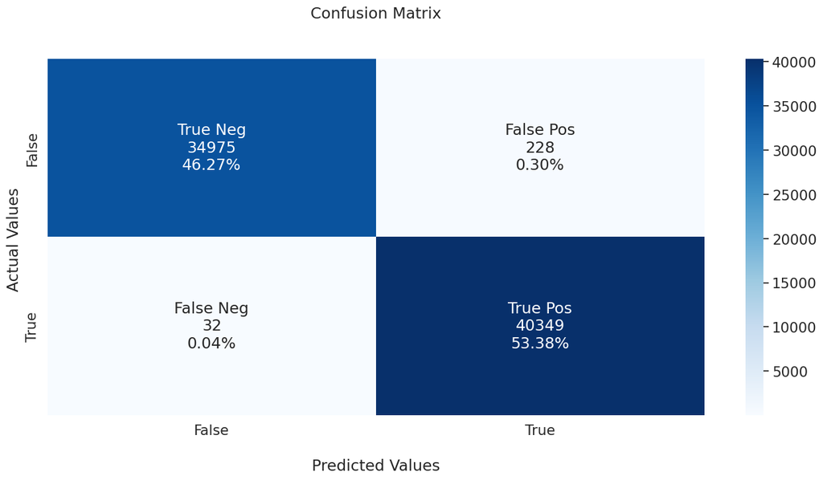

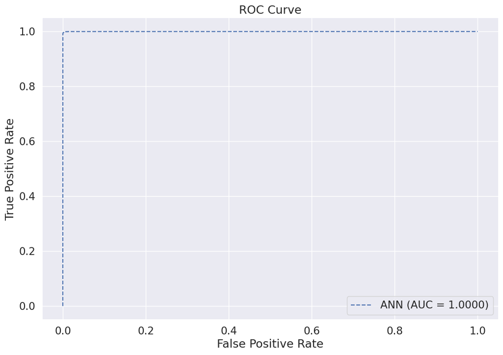

```python
# Create the ANN model
model_3 = Sequential()
model_3.add(Dense(1024, activation='relu', input_shape=(42,), kernel_constraint=MaxNorm(3)))
model_3.add(Dropout(0.5))
model_3.add(BatchNormalization())

model_3.add(Dense(1024, activation='relu', kernel_constraint=MaxNorm(3)))
model_3.add(Dropout(0.5))
model_3.add(BatchNormalization())

model_3.add(Dense(500, activation='relu', kernel_constraint=MaxNorm(3)))
model_3.add(Dropout(0.5))
model_3.add(BatchNormalization())

model_3.add(Dense(250, activation='relu', kernel_constraint=MaxNorm(3)))
model_3.add(Dropout(0.5))
model_3.add(BatchNormalization())

model_3.add(Dense(50, activation='relu', kernel_constraint=MaxNorm(3)))
model_3.add(Dropout(0.5))
model_3.add(BatchNormalization())

model_3.add(Dense(1, activation='sigmoid', kernel_constraint=MaxNorm(3)))
model_3.summary()

# Compile the model
model_3.compile(loss='binary_crossentropy', optimizer='adam', metrics=['accuracy'])

# Training time
start_train = time.time()
history = model_3.fit(X_train, y_train, epochs=10, batch_size=256,
                      validation_data=(X_test, y_test), verbose=1, shuffle=False)
end_train = time.time()
training_time = end_train - start_train
print(f"Training Time: {training_time:.2f} seconds")

# Testing time
start_test = time.time()
loss, accuracy = model_3.evaluate(X_test, y_test)
end_test = time.time()
testing_time = end_test - start_test
print(f"Testing Time: {testing_time:.2f} seconds")

# Total time
total_time = training_time + testing_time
print(f"Total Time (Training + Testing): {total_time:.2f} seconds")

print(f"Test Accuracy: {accuracy}")

# Make predictions
y_pred_prob = model_3.predict(X_test)
y_pred = np.round(y_pred_prob).astype(int)

# Calculate various metrics
accuracy = accuracy_score(y_test, y_pred)
precision = precision_score(y_test, y_pred)
recall = recall_score(y_test, y_pred)
f1 = f1_score(y_test, y_pred)
mcc = matthews_corrcoef(y_test, y_pred)
roc_auc3 = roc_auc_score(y_test, y_pred_prob)

# Print metrics
print(f"Accuracy: {accuracy}")
print(f"Precision: {precision}")
print(f"Recall: {recall}")
print(f"F1 Score: {f1}")
print(f"Matthews Correlation Coefficient: {mcc}")
print(f"ROC AUC Score: {roc_auc3}")
print("Classification Report:\n", classification_report(y_test, y_pred))

# Confusion matrix
conf_matrix = confusion_matrix(y_test, y_pred)

plt.figure(figsize=(16, 7))
sns.set(font_scale=1.4)

group_names = ['True Neg', 'False Pos', 'False Neg', 'True Pos']
group_counts = ["{0:0.0f}".format(value) for value in conf_matrix.flatten()]
group_percentages = ["{0:.2%}".format(value) for value in conf_matrix.flatten()/np.sum(conf_matrix)]

labels = [f"{v1}\n{v2}\n{v3}" for v1, v2, v3 in zip(group_names, group_counts, group_percentages)]
labels = np.asarray(labels).reshape(2, 2)

ax = sns.heatmap(conf_matrix, annot=labels, fmt='', cmap='Blues')
ax.set_title('Confusion Matrix\n\n')
ax.set_xlabel('\nPredicted Values')
ax.set_ylabel('Actual Values ')
ax.xaxis.set_ticklabels(['False', 'True'])
ax.yaxis.set_ticklabels(['False', 'True'])
plt.show()

print('*******************************************')

# ROC curve and AUC
fpr3, tpr3, _ = roc_curve(y_test, y_pred_prob)

plt.figure(figsize=(12, 8))
plt.plot(fpr3, tpr3, linestyle='--', label=f'ANN (AUC = {roc_auc3:.4f})')
plt.title('ROC Curve')
plt.xlabel('False Positive Rate')
plt.ylabel('True Positive Rate')
plt.legend()
plt.show()
```

# ANN-2-Model

```
Model: "sequential_2"
```

```
┏━━━━━━━━━━━━━━━━━━━━━━━━━━━━━━━━━┳━━━━━━━━━━━━━━━━━━━━━━━━┳━━━━━━━━━━━━━━━┓
┃ Layer (type)                    ┃ Output Shape           ┃       Param # ┃
┡━━━━━━━━━━━━━━━━━━━━━━━━━━━━━━━━━╇━━━━━━━━━━━━━━━━━━━━━━━━╇━━━━━━━━━━━━━━━┩
│ dense_10 (Dense)                │ (None, 1000)           │        43,000 │
├─────────────────────────────────┼────────────────────────┼───────────────┤
│ dropout_9 (Dropout)             │ (None, 1000)           │             0 │
├─────────────────────────────────┼────────────────────────┼───────────────┤
│ batch_normalization_5           │ (None, 1000)           │         4,000 │
│ (BatchNormalization)            │                        │               │
├─────────────────────────────────┼────────────────────────┼───────────────┤
│ dense_11 (Dense)                │ (None, 750)            │       750,750 │
├─────────────────────────────────┼────────────────────────┼───────────────┤
│ dropout_10 (Dropout)            │ (None, 750)            │             0 │
├─────────────────────────────────┼────────────────────────┼───────────────┤
│ batch_normalization_6           │ (None, 750)            │         3,000 │
│ (BatchNormalization)            │                        │               │
├─────────────────────────────────┼────────────────────────┼───────────────┤
│ dense_12 (Dense)                │ (None, 1)              │           751 │
└─────────────────────────────────┴────────────────────────┴───────────────┘
```

```
 Total params: 801,501 (3.06 MB)
```

```
 Trainable params: 798,001 (3.04 MB)
```

```
 Non-trainable params: 3,500 (13.67 KB)
```

```
689/689 ━━━━━━━━━━━━━━━━━━━━ 10s 8ms/step - accuracy: 0.9766 - loss: 0.0618 - val_accuracy: 0.9952 - val_loss: 0.0148
689/689 ━━━━━━━━━━━━━━━━━━━━ 3s 4ms/step - accuracy: 0.9941 - loss: 0.0172 - val_accuracy: 0.9959 - val_loss: 0.0122
689/689 ━━━━━━━━━━━━━━━━━━━━ 3s 4ms/step - accuracy: 0.9949 - loss: 0.0139 - val_accuracy: 0.9959 - val_loss: 0.0128
689/689 ━━━━━━━━━━━━━━━━━━━━ 3s 4ms/step - accuracy: 0.9950 - loss: 0.0134 - val_accuracy: 0.9963 - val_loss: 0.0114
689/689 ━━━━━━━━━━━━━━━━━━━━ 3s 4ms/step - accuracy: 0.9954 - loss: 0.0118 - val_accuracy: 0.9967 - val_loss: 0.0124
689/689 ━━━━━━━━━━━━━━━━━━━━ 3s 4ms/step - accuracy: 0.9960 - loss: 0.0107 - val_accuracy: 0.9970 - val_loss: 0.0102
689/689 ━━━━━━━━━━━━━━━━━━━━ 3s 4ms/step - accuracy: 0.9959 - loss: 0.0104 - val_accuracy: 0.9971 - val_loss: 0.0099
689/689 ━━━━━━━━━━━━━━━━━━━━ 3s 4ms/step - accuracy: 0.9960 - loss: 0.0103 - val_accuracy: 0.9964 - val_loss: 0.0111
689/689 ━━━━━━━━━━━━━━━━━━━━ 3s 4ms/step - accuracy: 0.9963 - loss: 0.0100 - val_accuracy: 0.9976 - val_loss: 0.0091
689/689 ━━━━━━━━━━━━━━━━━━━━ 3s 4ms/step - accuracy: 0.9965 - loss: 0.0092 - val_accuracy: 0.9971 - val_loss: 0.0098
Training Time: 34.20 seconds
2362/2362 ━━━━━━━━━━━━━━━━━━━━ 5s 2ms/step - accuracy: 0.9972 - loss: 0.0091
Testing Time: 4.69 seconds
Total Time (Training + Testing): 38.89 seconds
Test Accuracy: 0.9971
2362/2362 ━━━━━━━━━━━━━━━━━━━━ 3s 1ms/step
Accuracy: 0.9971
Precision: 0.9954
Recall: 0.9992
F1 Score: 0.9973
Matthews Correlation Coefficient: 0.9942
ROC AUC Score: 0.9999
Classification Report:
               precision    recall  f1-score   support

           0       1.00      0.99      1.00     35203
           1       1.00      1.00      1.00     40381

    accuracy                           1.00     75584
   macro avg       1.00      1.00      1.00     75584
weighted avg       1.00      1.00      1.00     75584
```

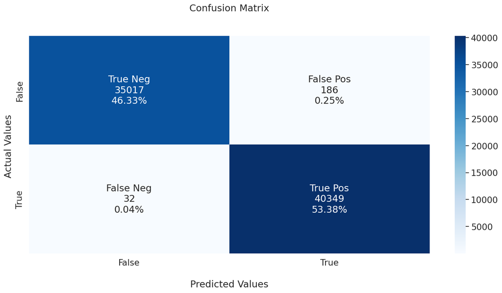

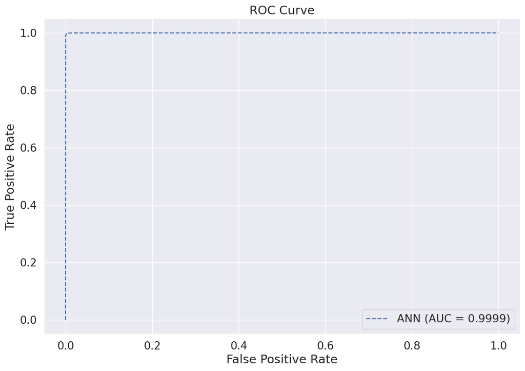

```python
# Create the ANN model
model_4 = Sequential()
model_4.add(Dense(1000, activation='relu', input_shape=(42,), kernel_constraint=MaxNorm(3)))
model_4.add(Dropout(0.7))
model_4.add(BatchNormalization())

model_4.add(Dense(750, activation='relu', kernel_constraint=MaxNorm(3)))
model_4.add(Dropout(0.7))
model_4.add(BatchNormalization())

model_4.add(Dense(1, activation='sigmoid', kernel_constraint=MaxNorm(3)))
model_4.summary()

# Compile the model
model_4.compile(loss='binary_crossentropy', optimizer='adam', metrics=['accuracy'])

# Training time
start_train = time.time()
history = model_4.fit(X_train, y_train, epochs=10, batch_size=256,
                      validation_data=(X_test, y_test), verbose=1, shuffle=False)
end_train = time.time()
training_time = end_train - start_train
print(f"Training Time: {training_time:.2f} seconds")

# Testing time
start_test = time.time()
loss, accuracy = model_4.evaluate(X_test, y_test)
end_test = time.time()
testing_time = end_test - start_test
print(f"Testing Time: {testing_time:.2f} seconds")

# Total time
total_time = training_time + testing_time
print(f"Total Time (Training + Testing): {total_time:.2f} seconds")

print(f"Test Accuracy: {accuracy:.4f}")

# Make predictions
y_pred_prob = model_4.predict(X_test)
y_pred = np.round(y_pred_prob).astype(int)  # Convert predictions to binary

# Calculate various metrics
accuracy = accuracy_score(y_test, y_pred)
precision = precision_score(y_test, y_pred)
recall = recall_score(y_test, y_pred)
f1 = f1_score(y_test, y_pred)
mcc = matthews_corrcoef(y_test, y_pred)
roc_auc4 = roc_auc_score(y_test, y_pred_prob)

# Print metrics
print(f"Accuracy: {accuracy:.4f}")
print(f"Precision: {precision:.4f}")
print(f"Recall: {recall:.4f}")
print(f"F1 Score: {f1:.4f}")
print(f"Matthews Correlation Coefficient: {mcc:.4f}")
print(f"ROC AUC Score: {roc_auc4:.4f}")
print("Classification Report:\n", classification_report(y_test, y_pred))

# Confusion matrix
conf_matrix = confusion_matrix(y_test, y_pred)

plt.figure(figsize=(16, 7))
sns.set(font_scale=1.4)

group_names = ['True Neg', 'False Pos', 'False Neg', 'True Pos']
group_counts = ["{0:0.0f}".format(value) for value in conf_matrix.flatten()]
group_percentages = ["{0:.2%}".format(value) for value in conf_matrix.flatten()/np.sum(conf_matrix)]

labels = [f"{v1}\n{v2}\n{v3}" for v1, v2, v3 in zip(group_names, group_counts, group_percentages)]
labels = np.asarray(labels).reshape(2, 2)

ax = sns.heatmap(conf_matrix, annot=labels, fmt='', cmap='Blues')
ax.set_title('Confusion Matrix\n\n')
ax.set_xlabel('\nPredicted Values')
ax.set_ylabel('Actual Values ')
ax.xaxis.set_ticklabels(['False', 'True'])
ax.yaxis.set_ticklabels(['False', 'True'])
plt.show()

print('*******************************************')

# ROC curve and AUC
fpr4, tpr4, _ = roc_curve(y_test, y_pred_prob)

plt.figure(figsize=(12, 8))
plt.plot(fpr4, tpr4, linestyle='--', label=f'ANN (AUC = {roc_auc4:.4f})')

plt.title('ROC Curve')
plt.xlabel('False Positive Rate')
plt.ylabel('True Positive Rate')
plt.legend()
plt.show()
```

# RNN-Model

```
Model: "RNN-Model"
```

```
┏━━━━━━━━━━━━━━━━━━━━━━━━━━━━━━━━━┳━━━━━━━━━━━━━━━━━━━━━━━━┳━━━━━━━━━━━━━━━┓
┃ Layer (type)                    ┃ Output Shape           ┃       Param # ┃
┡━━━━━━━━━━━━━━━━━━━━━━━━━━━━━━━━━╇━━━━━━━━━━━━━━━━━━━━━━━━╇━━━━━━━━━━━━━━━┩
│ simple_rnn (SimpleRNN)          │ (None, 42, 128)        │        16,640 │
├─────────────────────────────────┼────────────────────────┼───────────────┤
│ simple_rnn_1 (SimpleRNN)        │ (None, 42, 64)         │        12,352 │
├─────────────────────────────────┼────────────────────────┼───────────────┤
│ dropout_11 (Dropout)            │ (None, 42, 64)         │             0 │
├─────────────────────────────────┼────────────────────────┼───────────────┤
│ simple_rnn_2 (SimpleRNN)        │ (None, 32)             │         3,104 │
├─────────────────────────────────┼────────────────────────┼───────────────┤
│ flatten_2 (Flatten)             │ (None, 32)             │             0 │
├─────────────────────────────────┼────────────────────────┼───────────────┤
│ dense_13 (Dense)                │ (None, 32)             │         1,056 │
├─────────────────────────────────┼────────────────────────┼───────────────┤
│ dropout_12 (Dropout)            │ (None, 32)             │             0 │
├─────────────────────────────────┼────────────────────────┼───────────────┤
│ dense_14 (Dense)                │ (None, 1)              │            33 │
├─────────────────────────────────┼────────────────────────┼───────────────┤
│ activation_2 (Activation)       │ (None, 1)              │             0 │
└─────────────────────────────────┴────────────────────────┴───────────────┘
```

```
 Total params: 33,185 (129.63 KB)
```

```
 Trainable params: 33,185 (129.63 KB)
```

```
 Non-trainable params: 0 (0.00 B)
```

```
689/689 ━━━━━━━━━━━━━━━━━━━━ 21s 19ms/step - accuracy: 0.9768 - loss: 0.0672 - val_accuracy: 0.9945 - val_loss: 0.0143
689/689 ━━━━━━━━━━━━━━━━━━━━ 9s 13ms/step - accuracy: 0.9926 - loss: 0.0201 - val_accuracy: 0.9967 - val_loss: 0.0083
689/689 ━━━━━━━━━━━━━━━━━━━━ 9s 13ms/step - accuracy: 0.9959 - loss: 0.0108 - val_accuracy: 0.9977 - val_loss: 0.0072
689/689 ━━━━━━━━━━━━━━━━━━━━ 9s 13ms/step - accuracy: 0.9963 - loss: 0.0097 - val_accuracy: 0.9971 - val_loss: 0.0067
689/689 ━━━━━━━━━━━━━━━━━━━━ 9s 13ms/step - accuracy: 0.9965 - loss: 0.0091 - val_accuracy: 0.9975 - val_loss: 0.0070
689/689 ━━━━━━━━━━━━━━━━━━━━ 9s 13ms/step - accuracy: 0.9972 - loss: 0.0073 - val_accuracy: 0.9981 - val_loss: 0.0044
689/689 ━━━━━━━━━━━━━━━━━━━━ 9s 13ms/step - accuracy: 0.9970 - loss: 0.0073 - val_accuracy: 0.9974 - val_loss: 0.0069
689/689 ━━━━━━━━━━━━━━━━━━━━ 9s 13ms/step - accuracy: 0.9977 - loss: 0.0058 - val_accuracy: 0.9977 - val_loss: 0.0056
689/689 ━━━━━━━━━━━━━━━━━━━━ 9s 13ms/step - accuracy: 0.9966 - loss: 0.0088 - val_accuracy: 0.9979 - val_loss: 0.0059
689/689 ━━━━━━━━━━━━━━━━━━━━ 9s 13ms/step - accuracy: 0.9975 - loss: 0.0064 - val_accuracy: 0.9980 - val_loss: 0.0054
Training Time: 102.50 seconds
2362/2362 ━━━━━━━━━━━━━━━━━━━━ 9s 4ms/step - accuracy: 0.9980 - loss: 0.0052
Testing Time: 9.36 seconds
Total (Training + Testing) Time: 111.87 seconds
Test Accuracy: 0.997975766658783
2362/2362 ━━━━━━━━━━━━━━━━━━━━ 8s 3ms/step
Precision: 0.9975510809874834
Recall: 0.9986627374260172
F1 Score: 0.9981065996757708
Matthews Correlation Coefficient: 0.9959328138710238
ROC AUC Score: 0.9999788847576012
Classification Report:
               precision    recall  f1-score   support

           0       1.00      1.00      1.00     35203
           1       1.00      1.00      1.00     40381

    accuracy                           1.00     75584
   macro avg       1.00      1.00      1.00     75584
weighted avg       1.00      1.00      1.00     75584
```

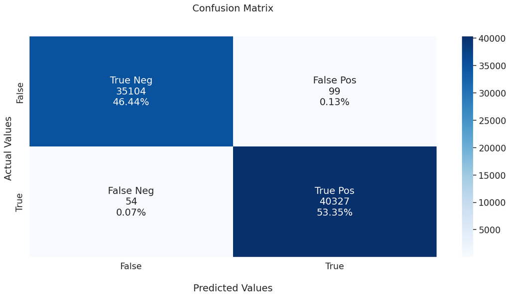

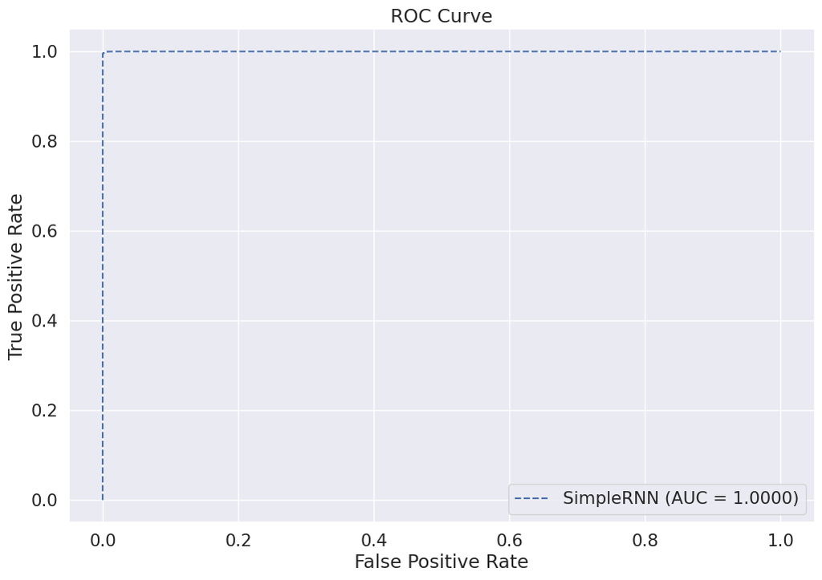

```python
# Define the model using RNN
model_5 = Sequential(name="RNN-Model")
model_5.add(SimpleRNN(units=128, input_shape=(42, 1), return_sequences=True))
model_5.add(SimpleRNN(units=64, return_sequences=True))
model_5.add(Dropout(0.01))
model_5.add(SimpleRNN(32))
model_5.add(Flatten())
model_5.add(Dense(units=32, activation='relu'))
model_5.add(Dropout(0.01))
model_5.add(Dense(units=1))
model_5.add(Activation('sigmoid'))
model_5.summary()

# Compile the model
model_5.compile(loss='binary_crossentropy', optimizer='adam', metrics=['accuracy'])

# Track training time
start_train = time.time()
history = model_5.fit(
    X_train, y_train,
    epochs=10,
    batch_size=256,
    validation_data=(X_test, y_test),
    verbose=1,
    shuffle=False
)
end_train = time.time()
training_time = end_train - start_train
print(f"Training Time: {training_time:.2f} seconds")

# Track testing (evaluation) time
start_test = time.time()
loss, accuracy = model_5.evaluate(X_test, y_test)
end_test = time.time()
testing_time = end_test - start_test
print(f"Testing Time: {testing_time:.2f} seconds")

# Total time
total_time = training_time + testing_time
print(f"Total (Training + Testing) Time: {total_time:.2f} seconds")

print(f"Test Accuracy: {accuracy}")

# Make predictions
y_pred_prob = model_5.predict(X_test)
y_pred = np.round(y_pred_prob).astype(int)  # Convert predictions to binary

# Calculate various metrics
precision = precision_score(y_test, y_pred)
recall = recall_score(y_test, y_pred)
f1 = f1_score(y_test, y_pred)
mcc = matthews_corrcoef(y_test, y_pred)
roc_auc5 = roc_auc_score(y_test, y_pred_prob)

# Print metrics
print(f"Precision: {precision}")
print(f"Recall: {recall}")
print(f"F1 Score: {f1}")
print(f"Matthews Correlation Coefficient: {mcc}")
print(f"ROC AUC Score: {roc_auc5}")
print("Classification Report:\n", classification_report(y_test, y_pred))

# Confusion matrix
conf_matrix = confusion_matrix(y_test, y_pred)

plt.figure(figsize=(16, 7))
sns.set(font_scale=1.4)

group_names = ['True Neg', 'False Pos', 'False Neg', 'True Pos']
group_counts = ["{0:0.0f}".format(value) for value in conf_matrix.flatten()]
group_percentages = ["{0:.2%}".format(value) for value in conf_matrix.flatten() / np.sum(conf_matrix)]

labels = [f"{v1}\n{v2}\n{v3}" for v1, v2, v3 in zip(group_names, group_counts, group_percentages)]
labels = np.asarray(labels).reshape(2, 2)

ax = sns.heatmap(conf_matrix, annot=labels, fmt='', cmap='Blues')
ax.set_title('Confusion Matrix\n\n')
ax.set_xlabel('\nPredicted Values')
ax.set_ylabel('Actual Values ')
ax.xaxis.set_ticklabels(['False', 'True'])
ax.yaxis.set_ticklabels(['False', 'True'])

plt.show()

print('*******************************************')

# ROC curve and AUC
fpr5, tpr5, _ = roc_curve(y_test, y_pred_prob)

plt.figure(figsize=(12, 8))
plt.plot(fpr5, tpr5, linestyle='--', label=f'SimpleRNN (AUC = {roc_auc5:.4f})')

plt.title('ROC Curve')
plt.xlabel('False Positive Rate')
plt.ylabel('True Positive Rate')
plt.legend()
plt.show()
```

```
Model: "GRU-Model"
```

```
┏━━━━━━━━━━━━━━━━━━━━━━━━━━━━━━━━━┳━━━━━━━━━━━━━━━━━━━━━━━━┳━━━━━━━━━━━━━━━┓
┃ Layer (type)                    ┃ Output Shape           ┃       Param # ┃
┡━━━━━━━━━━━━━━━━━━━━━━━━━━━━━━━━━╇━━━━━━━━━━━━━━━━━━━━━━━━╇━━━━━━━━━━━━━━━┩
│ gru (GRU)                       │ (None, 42, 128)        │        50,304 │
├─────────────────────────────────┼────────────────────────┼───────────────┤
│ gru_1 (GRU)                     │ (None, 42, 64)         │        37,248 │
├─────────────────────────────────┼────────────────────────┼───────────────┤
│ dropout_13 (Dropout)            │ (None, 42, 64)         │             0 │
├─────────────────────────────────┼────────────────────────┼───────────────┤
│ flatten_3 (Flatten)             │ (None, 2688)           │             0 │
├─────────────────────────────────┼────────────────────────┼───────────────┤
│ dense_15 (Dense)                │ (None, 32)             │        86,048 │
├─────────────────────────────────┼────────────────────────┼───────────────┤
│ dropout_14 (Dropout)            │ (None, 32)             │             0 │
├─────────────────────────────────┼────────────────────────┼───────────────┤
│ dense_16 (Dense)                │ (None, 1)              │            33 │
├─────────────────────────────────┼────────────────────────┼───────────────┤
│ activation_3 (Activation)       │ (None, 1)              │             0 │
└─────────────────────────────────┴────────────────────────┴───────────────┘
```

```
 Total params: 173,633 (678.25 KB)
```

```
 Trainable params: 173,633 (678.25 KB)
```

```
 Non-trainable params: 0 (0.00 B)
```

```
689/689 ━━━━━━━━━━━━━━━━━━━━ 11s 11ms/step - accuracy: 0.9665 - loss: 0.0936 - val_accuracy: 0.9953 - val_loss: 0.0124
689/689 ━━━━━━━━━━━━━━━━━━━━ 7s 11ms/step - accuracy: 0.9956 - loss: 0.0120 - val_accuracy: 0.9968 - val_loss: 0.0076
689/689 ━━━━━━━━━━━━━━━━━━━━ 7s 11ms/step - accuracy: 0.9967 - loss: 0.0083 - val_accuracy: 0.9978 - val_loss: 0.0052
689/689 ━━━━━━━━━━━━━━━━━━━━ 7s 11ms/step - accuracy: 0.9975 - loss: 0.0066 - val_accuracy: 0.9982 - val_loss: 0.0046
689/689 ━━━━━━━━━━━━━━━━━━━━ 7s 11ms/step - accuracy: 0.9980 - loss: 0.0050 - val_accuracy: 0.9981 - val_loss: 0.0041
689/689 ━━━━━━━━━━━━━━━━━━━━ 7s 11ms/step - accuracy: 0.9983 - loss: 0.0046 - val_accuracy: 0.9987 - val_loss: 0.0030
689/689 ━━━━━━━━━━━━━━━━━━━━ 7s 11ms/step - accuracy: 0.9985 - loss: 0.0036 - val_accuracy: 0.9988 - val_loss: 0.0029
689/689 ━━━━━━━━━━━━━━━━━━━━ 7s 11ms/step - accuracy: 0.9986 - loss: 0.0036 - val_accuracy: 0.9988 - val_loss: 0.0029
689/689 ━━━━━━━━━━━━━━━━━━━━ 7s 11ms/step - accuracy: 0.9988 - loss: 0.0032 - val_accuracy: 0.9990 - val_loss: 0.0025
689/689 ━━━━━━━━━━━━━━━━━━━━ 7s 11ms/step - accuracy: 0.9986 - loss: 0.0032 - val_accuracy: 0.9990 - val_loss: 0.0022
Training Time: 76.88 seconds
2362/2362 ━━━━━━━━━━━━━━━━━━━━ 8s 4ms/step - accuracy: 0.9991 - loss: 0.0022
Testing Time: 8.46 seconds
Total (Training + Testing) Time: 85.34 seconds
Test Accuracy: 0.9990341663360596
2362/2362 ━━━━━━━━━━━━━━━━━━━━ 6s 2ms/step
Precision: 0.9991331913418198
Recall: 0.9990589633738639
F1 Score: 0.9990960759791477
Matthews Correlation Coefficient: 0.9980592798837168
ROC AUC Score: 0.9999961780679653
Classification Report:
               precision    recall  f1-score   support

           0       1.00      1.00      1.00     35203
           1       1.00      1.00      1.00     40381

    accuracy                           1.00     75584
   macro avg       1.00      1.00      1.00     75584
weighted avg       1.00      1.00      1.00     75584
```

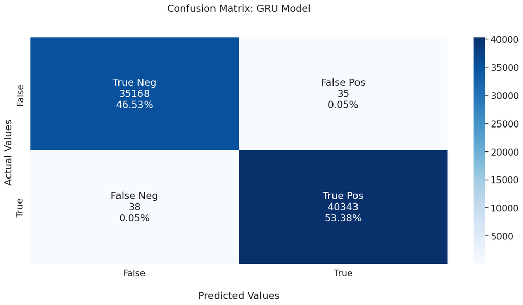

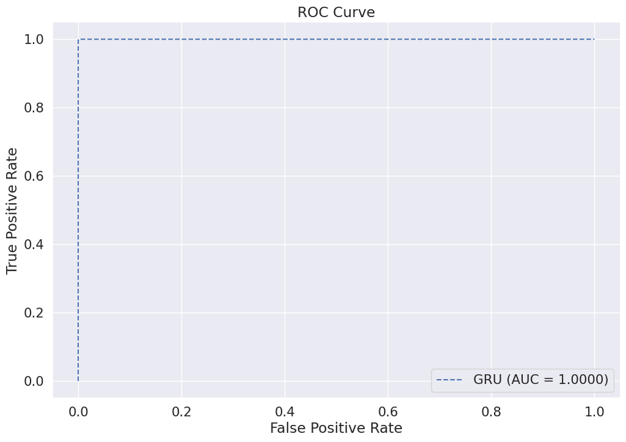

```python
# Define the model using GRU
model_gru = Sequential(name="GRU-Model")
model_gru.add(GRU(units=128, input_shape=(42, 1), return_sequences=True))
model_gru.add(GRU(units=64, return_sequences=True))
model_gru.add(Dropout(0.03))
model_gru.add(Flatten())
model_gru.add(Dense(units=32, activation='relu'))
model_gru.add(Dropout(0.03))
model_gru.add(Dense(units=1))
model_gru.add(Activation('sigmoid'))
model_gru.summary()

# Compile the model
model_gru.compile(loss='binary_crossentropy', optimizer='adam', metrics=['accuracy'])

# Track training time
start_train = time.time()
history = model_gru.fit(
    X_train, y_train,
    epochs=10,
    batch_size=256,
    validation_data=(X_test, y_test),
    verbose=1,
    shuffle=False
)
end_train = time.time()
training_time = end_train - start_train
print(f"Training Time: {training_time:.2f} seconds")

# Track testing (evaluation) time
start_test = time.time()
loss, accuracy = model_gru.evaluate(X_test, y_test)
end_test = time.time()
testing_time = end_test - start_test
print(f"Testing Time: {testing_time:.2f} seconds")

# Total time
total_time = training_time + testing_time
print(f"Total (Training + Testing) Time: {total_time:.2f} seconds")

print(f"Test Accuracy: {accuracy}")

# Make predictions
y_pred_prob = model_gru.predict(X_test)
y_pred = np.round(y_pred_prob).astype(int)  # Convert predictions to binary

# Calculate various metrics
precision = precision_score(y_test, y_pred)
recall = recall_score(y_test, y_pred)
f1 = f1_score(y_test, y_pred)
mcc = matthews_corrcoef(y_test, y_pred)
roc_auc_gru = roc_auc_score(y_test, y_pred_prob)

# Print metrics
print(f"Precision: {precision}")
print(f"Recall: {recall}")
print(f"F1 Score: {f1}")
print(f"Matthews Correlation Coefficient: {mcc}")
print(f"ROC AUC Score: {roc_auc_gru}")
print("Classification Report:\n", classification_report(y_test, y_pred))

# Confusion matrix
conf_matrix = confusion_matrix(y_test, y_pred)

plt.figure(figsize=(16, 7))
sns.set(font_scale=1.4)

group_names = ['True Neg', 'False Pos', 'False Neg', 'True Pos']
group_counts = ["{0:0.0f}".format(value) for value in conf_matrix.flatten()]
group_percentages = ["{0:.2%}".format(value) for value in conf_matrix.flatten() / np.sum(conf_matrix)]

labels = [f"{v1}\n{v2}\n{v3}" for v1, v2, v3 in zip(group_names, group_counts, group_percentages)]
labels = np.asarray(labels).reshape(2, 2)

ax = sns.heatmap(conf_matrix, annot=labels, fmt='', cmap='Blues')
ax.set_title('Confusion Matrix: GRU Model\n\n')
ax.set_xlabel('\nPredicted Values')
ax.set_ylabel('Actual Values ')
ax.xaxis.set_ticklabels(['False', 'True'])
ax.yaxis.set_ticklabels(['False', 'True'])

plt.show()

print('*******************************************')

# ROC curve and AUC
fpr_gru, tpr_gru, _ = roc_curve(y_test, y_pred_prob)

plt.figure(figsize=(12, 8))
plt.plot(fpr_gru, tpr_gru, linestyle='--', label=f'GRU (AUC = {roc_auc_gru:.4f})')

plt.title('ROC Curve')
plt.xlabel('False Positive Rate')
plt.ylabel('True Positive Rate')
plt.legend()
plt.show()
```

```
Iteration 1/5, Best Fitness = 0.9978
Iteration 2/5, Best Fitness = 0.9978
Iteration 3/5, Best Fitness = 0.9978
Iteration 4/5, Best Fitness = 0.9978
Iteration 5/5, Best Fitness = 0.9979

Best Hyperparameters from Bee Algorithm:
  GRU Units Layer1 : 246
  GRU Units Layer2 : 69
  Dropout          : 0.010
  Batch Size       : 359
492/492 ━━━━━━━━━━━━━━━━━━━━ 14s 23ms/step - accuracy: 0.9578 - loss: 0.1112 - val_accuracy: 0.9951 - val_loss: 0.0131
492/492 ━━━━━━━━━━━━━━━━━━━━ 11s 23ms/step - accuracy: 0.9954 - loss: 0.0131 - val_accuracy: 0.9968 - val_loss: 0.0089
492/492 ━━━━━━━━━━━━━━━━━━━━ 11s 23ms/step - accuracy: 0.9966 - loss: 0.0086 - val_accuracy: 0.9980 - val_loss: 0.0052
492/492 ━━━━━━━━━━━━━━━━━━━━ 11s 22ms/step - accuracy: 0.9971 - loss: 0.0071 - val_accuracy: 0.9981 - val_loss: 0.0050
492/492 ━━━━━━━━━━━━━━━━━━━━ 11s 22ms/step - accuracy: 0.9981 - loss: 0.0053 - val_accuracy: 0.9983 - val_loss: 0.0040
492/492 ━━━━━━━━━━━━━━━━━━━━ 11s 22ms/step - accuracy: 0.9982 - loss: 0.0045 - val_accuracy: 0.9987 - val_loss: 0.0033
492/492 ━━━━━━━━━━━━━━━━━━━━ 11s 22ms/step - accuracy: 0.9984 - loss: 0.0045 - val_accuracy: 0.9986 - val_loss: 0.0039
492/492 ━━━━━━━━━━━━━━━━━━━━ 11s 22ms/step - accuracy: 0.9982 - loss: 0.0042 - val_accuracy: 0.9991 - val_loss: 0.0025
492/492 ━━━━━━━━━━━━━━━━━━━━ 11s 22ms/step - accuracy: 0.9986 - loss: 0.0037 - val_accuracy: 0.9992 - val_loss: 0.0025
492/492 ━━━━━━━━━━━━━━━━━━━━ 11s 22ms/step - accuracy: 0.9986 - loss: 0.0034 - val_accuracy: 0.9992 - val_loss: 0.0024
2362/2362 ━━━━━━━━━━━━━━━━━━━━ 9s 4ms/step - accuracy: 0.9993 - loss: 0.0022

 Training Time: 113.53 seconds
 Testing Time: 8.73 seconds
 Total Time: 122.26 seconds
 Final Test Accuracy: 0.9992
2362/2362 ━━━━━━━━━━━━━━━━━━━━ 6s 2ms/step
Precision: 0.9991
Recall: 0.9994
F1 Score: 0.9992
MCC: 0.9984
ROC AUC: 1.0000

Classification Report:
               precision    recall  f1-score   support

           0       1.00      1.00      1.00     35203
           1       1.00      1.00      1.00     40381

    accuracy                           1.00     75584
   macro avg       1.00      1.00      1.00     75584
weighted avg       1.00      1.00      1.00     75584
```

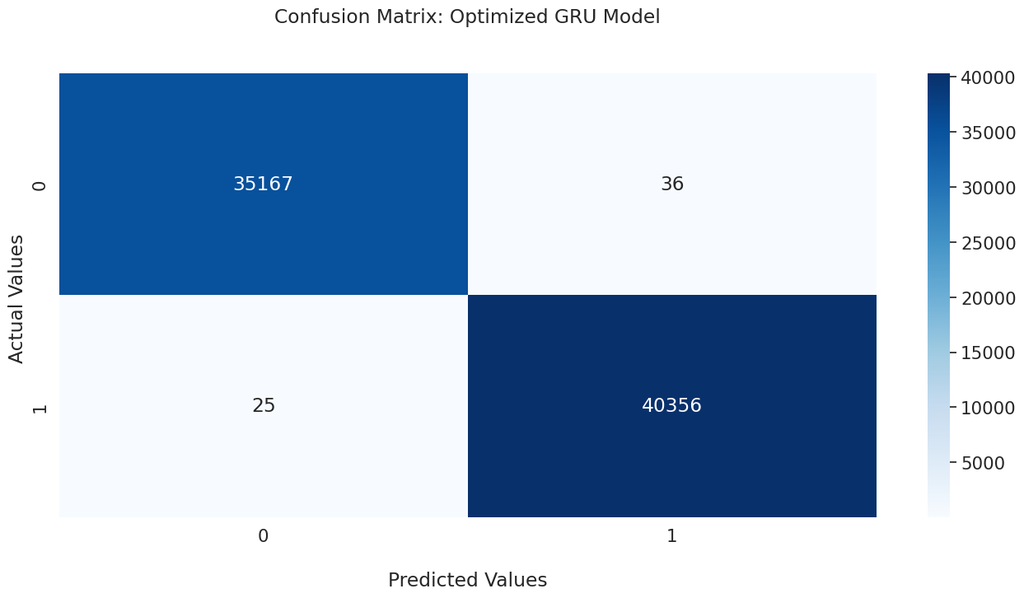

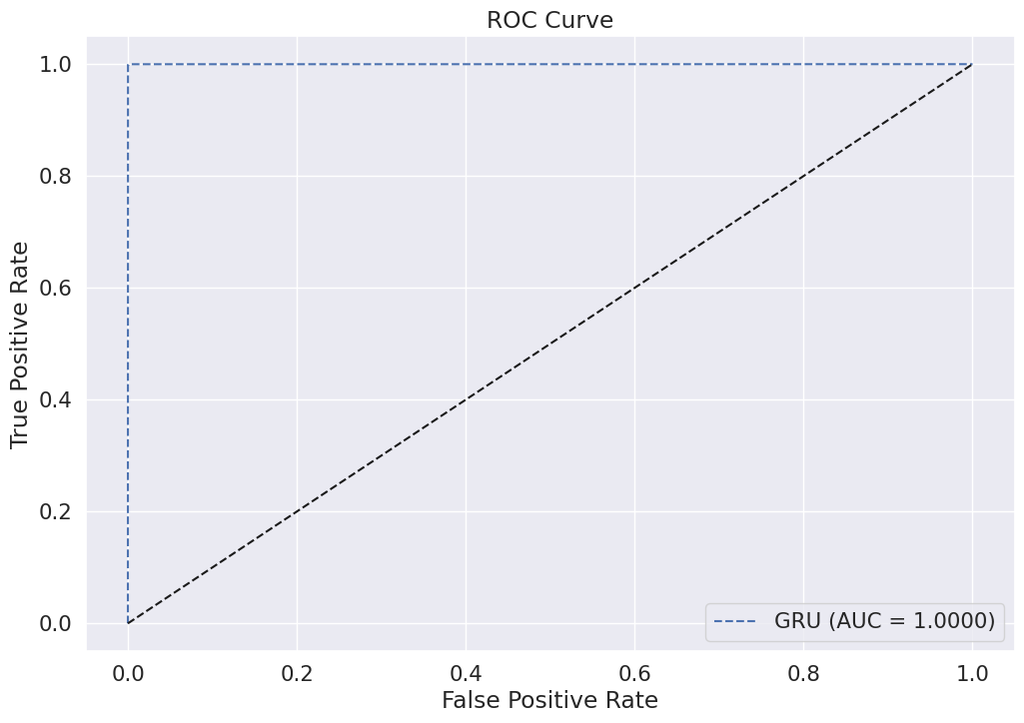

```python
# -----------------------------------------------------------
# Define Search Space: [units1, units2, dropout, batch_size]
# -----------------------------------------------------------
bounds = (
    np.array([32, 16, 0.01, 32]),   # lower bounds
    np.array([256, 128, 0.5, 512])  # upper bounds
)

# -----------------------------------------------------------
# Objective Function
# -----------------------------------------------------------
def objective_function(params):
    losses = []
    for p in params:
        units1 = int(p[0])
        units2 = int(p[1])
        dropout = float(p[2])
        batch_size = int(p[3])

        # Define GRU model
        model = Sequential(name="GRU-Model")
        model.add(GRU(units=units1, input_shape=(42, 1), return_sequences=True))
        model.add(GRU(units=units2, return_sequences=True))
        model.add(Dropout(dropout))
        model.add(Flatten())
        model.add(Dense(units=32, activation='relu'))
        model.add(Dropout(dropout))
        model.add(Dense(units=1))
        model.add(Activation('sigmoid'))

        model.compile(loss='binary_crossentropy', optimizer=Adam(), metrics=['accuracy'])

        # Train (only few epochs for optimization speed)
        history = model.fit(
            X_train, y_train,
            epochs=3,
            batch_size=batch_size,
            validation_split=0.2,
            verbose=0,
            shuffle=False
        )

        val_acc = np.max(history.history['val_accuracy'])
        losses.append(1 - val_acc)  # minimize loss (maximize val_acc)
    return np.array(losses)

# -----------------------------------------------------------
# Bee Algorithm
# -----------------------------------------------------------
class BeeOptimizer:
    def __init__(self, n_bees, n_elite, n_best, patch_size, bounds, max_iter):
        self.n_bees = n_bees
        self.n_elite = n_elite
        self.n_best = n_best
        self.patch_size = patch_size
        self.bounds = bounds
        self.max_iter = max_iter

    def optimize(self):
        population = np.random.uniform(self.bounds[0], self.bounds[1], (self.n_bees, len(self.bounds[0])))
        best_solution = None
        best_fitness = float('inf')

        for iteration in range(self.max_iter):
            fitness = objective_function(population)
            sorted_indices = np.argsort(fitness)
            population = population[sorted_indices]
            fitness = fitness[sorted_indices]

            if fitness[0] < best_fitness:
                best_fitness = fitness[0]
                best_solution = population[0]

            print(f"Iteration {iteration+1}/{self.max_iter}, Best Fitness = {1-best_fitness:.4f}")

            new_population = []
            for i in range(self.n_elite):
                for _ in range(self.n_best):
                    candidate = population[i] + np.random.uniform(-self.patch_size, self.patch_size, len(self.bounds[0]))
                    candidate = np.clip(candidate, self.bounds[0], self.bounds[1])
                    new_population.append(candidate)

            for i in range(self.n_elite, self.n_best + self.n_elite):
                if i < len(population):
                    candidate = population[i] + np.random.uniform(-self.patch_size, self.patch_size, len(self.bounds[0]))
                    candidate = np.clip(candidate, self.bounds[0], self.bounds[1])
                    new_population.append(candidate)

            while len(new_population) < self.n_bees:
                candidate = np.random.uniform(self.bounds[0], self.bounds[1], len(self.bounds[0]))
                new_population.append(candidate)

            population = np.array(new_population)

        return best_solution, 1 - best_fitness

# -----------------------------------------------------------
# Run Bee Algorithm
# -----------------------------------------------------------
optimizer = BeeOptimizer(n_bees=10, n_elite=3, n_best=3, patch_size=10, bounds=bounds, max_iter=5)
best_params, best_acc = optimizer.optimize()

best_units1 = int(best_params[0])
best_units2 = int(best_params[1])
best_dropout = float(best_params[2])
best_batch = int(best_params[3])

print("\nBest Hyperparameters from Bee Algorithm:")
print(f"  GRU Units Layer1 : {best_units1}")
print(f"  GRU Units Layer2 : {best_units2}")
print(f"  Dropout          : {best_dropout:.3f}")
print(f"  Batch Size       : {best_batch}")

# -----------------------------------------------------------
# Final GRU Training with Best Hyperparameters
# -----------------------------------------------------------
model_gru = Sequential(name="Optimized-GRU-Model")
model_gru.add(GRU(units=best_units1, input_shape=(42, 1), return_sequences=True))
model_gru.add(GRU(units=best_units2, return_sequences=True))
model_gru.add(Dropout(best_dropout))
model_gru.add(Flatten())
model_gru.add(Dense(units=32, activation='relu'))
model_gru.add(Dropout(best_dropout))
model_gru.add(Dense(units=1))
model_gru.add(Activation('sigmoid'))

model_gru.compile(loss='binary_crossentropy', optimizer=Adam(), metrics=['accuracy'])

# Training + Testing with Time
start_train = time.time()
history = model_gru.fit(
    X_train, y_train,
    epochs=10,
    batch_size=best_batch,
    validation_data=(X_test, y_test),
    verbose=1,
    shuffle=False
)
end_train = time.time()
train_time = end_train - start_train

start_test = time.time()
loss, accuracy = model_gru.evaluate(X_test, y_test)
end_test = time.time()
test_time = end_test - start_test

print(f"\n Training Time: {train_time:.2f} seconds")
print(f" Testing Time: {test_time:.2f} seconds")
print(f" Total Time: {train_time+test_time:.2f} seconds")
print(f" Final Test Accuracy: {accuracy:.4f}")

# -----------------------------------------------------------
# Evaluation Metrics
# -----------------------------------------------------------
y_pred_prob = model_gru.predict(X_test)
y_pred = np.round(y_pred_prob).astype(int)

precision = precision_score(y_test, y_pred)
recall = recall_score(y_test, y_pred)
f1 = f1_score(y_test, y_pred)
mcc = matthews_corrcoef(y_test, y_pred)
roc_auc_gru = roc_auc_score(y_test, y_pred_prob)

print(f"Precision: {precision:.4f}")
print(f"Recall: {recall:.4f}")
print(f"F1 Score: {f1:.4f}")
print(f"MCC: {mcc:.4f}")
print(f"ROC AUC: {roc_auc_gru:.4f}")
print("\nClassification Report:\n", classification_report(y_test, y_pred))

# -----------------------------------------------------------
# Confusion Matrix
# -----------------------------------------------------------
conf_matrix = confusion_matrix(y_test, y_pred)
plt.figure(figsize=(16, 7))
sns.set(font_scale=1.4)
ax = sns.heatmap(conf_matrix, annot=True, fmt='d', cmap='Blues')
ax.set_title('Confusion Matrix: Optimized GRU Model\n\n')
ax.set_xlabel('\nPredicted Values')
ax.set_ylabel('Actual Values ')
plt.show()

# -----------------------------------------------------------
# ROC Curve
# -----------------------------------------------------------
fpr, tpr, _ = roc_curve(y_test, y_pred_prob)
plt.figure(figsize=(12, 8))
plt.plot(fpr, tpr, linestyle='--', label=f'GRU (AUC = {roc_auc_gru:.4f})')
plt.plot([0,1],[0,1],'k--')
plt.title('ROC Curve')
plt.xlabel('False Positive Rate')
plt.ylabel('True Positive Rate')
plt.legend()
plt.show()
```